# Qploidy2 Tutorial

Large-scale copy number estimation in alfalfa mapping population using DArTag genotyping data

Breeding Insight

2026-10-27

# 1 Introduction

This tutorial demonstrates a typical workflow for ploidy and aneuploidy estimation using the Qploidy2 R package. We will cover data import, standardization, model selection, Hidden Markov Model (HMM)-based copy number estimation, visualization, and VCF export.

The dataset used here for our demonstration is an alfalfa mapping population genotyped using DArTag technology. Refer to [this publication](https://doi.org/10.5061/dryad.pc866t1vd) for more information about the dataset.

To start, download the example dataset to your local directory:

```r
vcf_path_web <- "https://github.com/Breeding-Insight/BIGapp-PanelHub/raw/refs/heads/long_seq/alfalfa/GenoBrew_example/alfalfa_F1_marker_panel_dataset_publicly_available.vcf.gz"
download.file(vcf_path_web, destfile = "alfalfa_F1_marker_panel_dataset_publicly_available.vcf.gz")
vcf_path_local <- "alfalfa_F1_marker_panel_dataset_publicly_available.vcf.gz"
```

# 2 Remarks

The Qploidy standardization methodology **is effective** under the following conditions:

- **Supported Sequencing Platforms**: Your marker data originates from Axiom or Illumina genotyping arrays, targeted sequencing platforms (e.g., DArTag, GTseq, AgriSeq), or whole-genome sequencing (WGS) platforms.
- **Batch effect**: All DNA samples were prepared following the same library preparation protocol *(check this section for more details)* For example: If you extracted DNA and sequenced two plates (192 samples) as one batch, and later sequenced an additional three plates (288 samples) as a second batch, you would need to analyze the two batches separately in Qploidy. Combining all 480 samples into a single analysis will lead to incorrect results due to batch effects.
- **Minimum previous knowledge**: You know the ploidy of at least a subset (rough minimum of 60 samples) or you know the most common ploidy in the dataset. The higher the number of samples with known or common ploidy, the better the results
- **Heterozygosity**: Your dataset includes heterozygous samples

The Qploidy2 B-allele frequency (BAF) model selection and HMM methodologies **are effective** under the following conditions:

- **Standardized data**: The ratio or BAF distributions of your samples present clear peaks corresponding to different copy numbers
- **Total read depth**: The total read depth or z-scores variations within a sample follows a normal distribution, with the mean shifting according to the copy number
- **Heterozygosity**: The sample includes heterozygous loci, which are essential for BAF-based ploidy estimation. Samples with heterozygosity lower than 5% will be considered haploid (CN = 1) and they cannot be distinguished from inbred lines with higher CN
- **Sequencing depth**: If allele counts are based on a sequencing platform, the sequencing should have enough depth to capture dosages of the highest possible copy number in the dataset
- **Number of markers**: The number of markers is sufficient to provide a good resolution for the BAF distributions
- **CN call resolution**: The larger the amount of markers, the smaller the copy number variations that can be detected

# 3 Install

- It requires R version superior to 3.6.0

Install Qploidy2 (if not already installed):

```r
devtools::install_github("Breeding-Insight/Qploidy2")
```

Check the package version:

```r
packageVersion("Qploidy2")
```

```
## [1] '1.22.0'
```

# 4 Input data

`Qploidy2` receives three main objects named: - marker-level data (`data`): should contain sample names, marker ID, allele counts/intensities ratio and total for all samples - marker positions (`geno.pos`): should contain marker IDs, and respective genomic chromosome and positions - genotype dosages (`genos`) - only required for standardization: contain samples names, marker ID, and dosage/genotype considering expected ploidy. The samples in this file should be the ones with a known ploidy or the full dataset with dosage called considering the predominant ploidy.

`Qploidy2` has functions to facilitate the conversion of standard file formats to these three objects. In this tutorial we will show the `qploidy_read_vcf` function for VCF conversion. The VCF must contain the AD field for allele counts. Check function `?read_axiom` and `?read_illumina_array` if your data comes from genotyping arrays.

```r
library(Qploidy2)

# Read marker-level data from VCF
data <- qploidy_read_vcf(vcf_path_local)
head(data)
```

|  | MarkerName | SampleName | X | Y | R | ratio |
| --- | --- | --- | --- | --- | --- | --- |
| 1 | chr1.1_000194324 | J432 | 0 | 264 | 264 | 1.0000000 |
| 2 | chr1.1_000194324 | 85-1 | 1 | 339 | 340 | 0.9970588 |
| 3 | chr1.1_000194324 | 85-100 | 0 | 239 | 239 | 1.0000000 |
| 4 | chr1.1_000194324 | 85-102 | 55 | 204 | 259 | 0.7876448 |
| 5 | chr1.1_000194324 | 85-103 | 53 | 211 | 264 | 0.7992424 |
| 6 | chr1.1_000194324 | 85-104 | 0 | 330 | 330 | 1.0000000 |

```r
# Read genotype dosages (optionally, restrict to samples with known ploidy)
genos <- qploidy_read_vcf(vcf_path_local, geno = TRUE)
head(genos)
```

|  | MarkerName | SampleName | geno | prob |
| --- | --- | --- | --- | --- |
| 1 | chr1.1_000194324 | 85-1 | 0 | NA |
| 2 | chr1.1_000194324 | 85-100 | 0 | NA |
| 3 | chr1.1_000194324 | 85-102 | 1 | NA |
| 4 | chr1.1_000194324 | 85-103 | 1 | NA |
| 5 | chr1.1_000194324 | 85-104 | 0 | NA |
| 6 | chr1.1_000194324 | 85-106 | 1 | NA |

```r
# Read marker positions
geno.pos <- qploidy_read_vcf(vcf_path_local, geno.pos = TRUE)
head(geno.pos)
```

|  | MarkerName | Chromosome | Position |
| --- | --- | --- | --- |
| 1 | chr1.1_000194324 | chr1.1 | 194324 |
| 2 | chr1.1_000452961 | chr1.1 | 452961 |
| 3 | chr1.1_000532584 | chr1.1 | 532584 |
| 4 | chr1.1_000735393 | chr1.1 | 735393 |
| 5 | chr1.1_000837330 | chr1.1 | 837330 |
| 6 | chr1.1_000915014 | chr1.1 | 915014 |

# 5 Check data initial status

The `plot_raw` function provides diagnostic plots for metrics that will be considered by `Qploidy2` copy number estimation. Here is a brief description of each from top to bottom:

- Heterozygosity: y-axis = proportion of heterozygous loci in a genomic window with size defined by argument `window_size` (default = 2Mb); x-axis = genomic positions
- Allele counts/intensities ratio (B/(A+B)): y-axis = ratio value; x-axis = genomic positions
- Ratio histogram split by chromosome: y-axis = observation counts; x-axis = ratio value
- Ratio histogram considering all markers of the samples: y-axis = observation counts; x-axis = ratio value
- Read depth (sequencing platforms) or total intensities (array) in y-axis and genomic position in x-axis

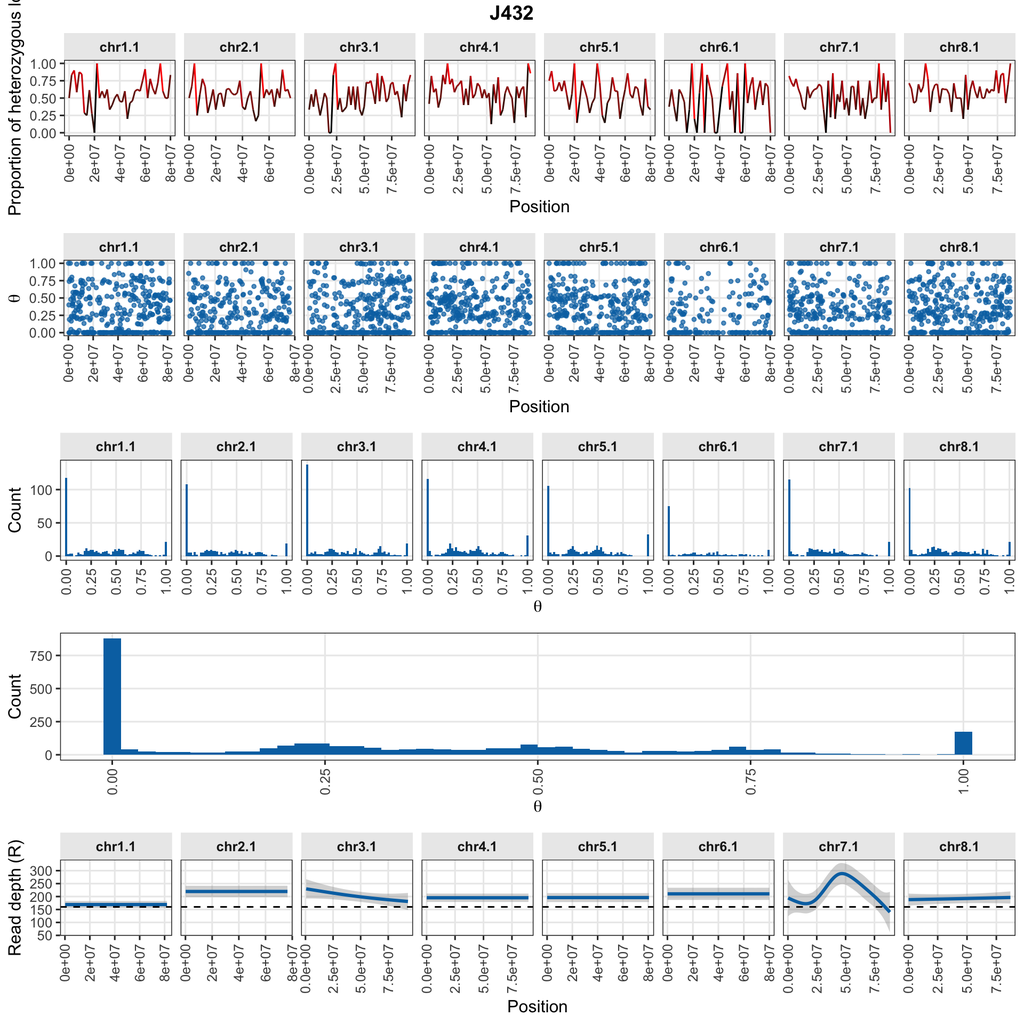

```r
samples <- unique(data$SampleName)
plot_raw(data = data,
         geno.pos = geno.pos,
         sample = samples[1])
```

Check the plots for a few samples. If the histograms do not show clear peaks, consider applying `Qploidy` standardization. If you already have clear peaks and do not want to try to improve them, skip to item `# BAF Model Selection`.

## 5.1 Check for batch effect before standardization

Qploidy2 standardization assumes that each marker behaves consistently across samples, while allowing markers to differ from one another. Depending on the genotyping platform, however, this assumption may not hold — particularly if DNA extraction protocols were modified or samples were processed in different plates or batches.

For example, you may have extracted DNA at one time point and sequenced a plate with 96 samples in a given year, then used the stored DNA two years later to sequence an additional 96 samples. Changes in DNA quality over time can affect probe performance, leading to systematic differences between batches. In such cases, standardization should be performed separately for each batch.

You can assess whether batch effects are present in your dataset using the following function:

```r
# provide a passport file (containing year of DNA extraction/plate number/ or any possible factor for a batch effect)
# This example dataset doesn't have a passport available, we will simulate one just to exemplify the function usage:
set.seed(123)
samples <- unique(data$SampleName)
passport_file <- data.frame(SampleName = samples, year_seq = sample(rep(c(2020, 2022, 2025), length(samples))))
head(passport_file)
```

|  | SampleName | year_seq |
| --- | --- | --- |
| 1 | J432 | 2020 |
| 2 | 85-1 | 2020 |
| 3 | 85-100 | 2022 |
| 4 | 85-102 | 2020 |
| 5 | 85-103 | 2025 |
| 6 | 85-104 | 2020 |

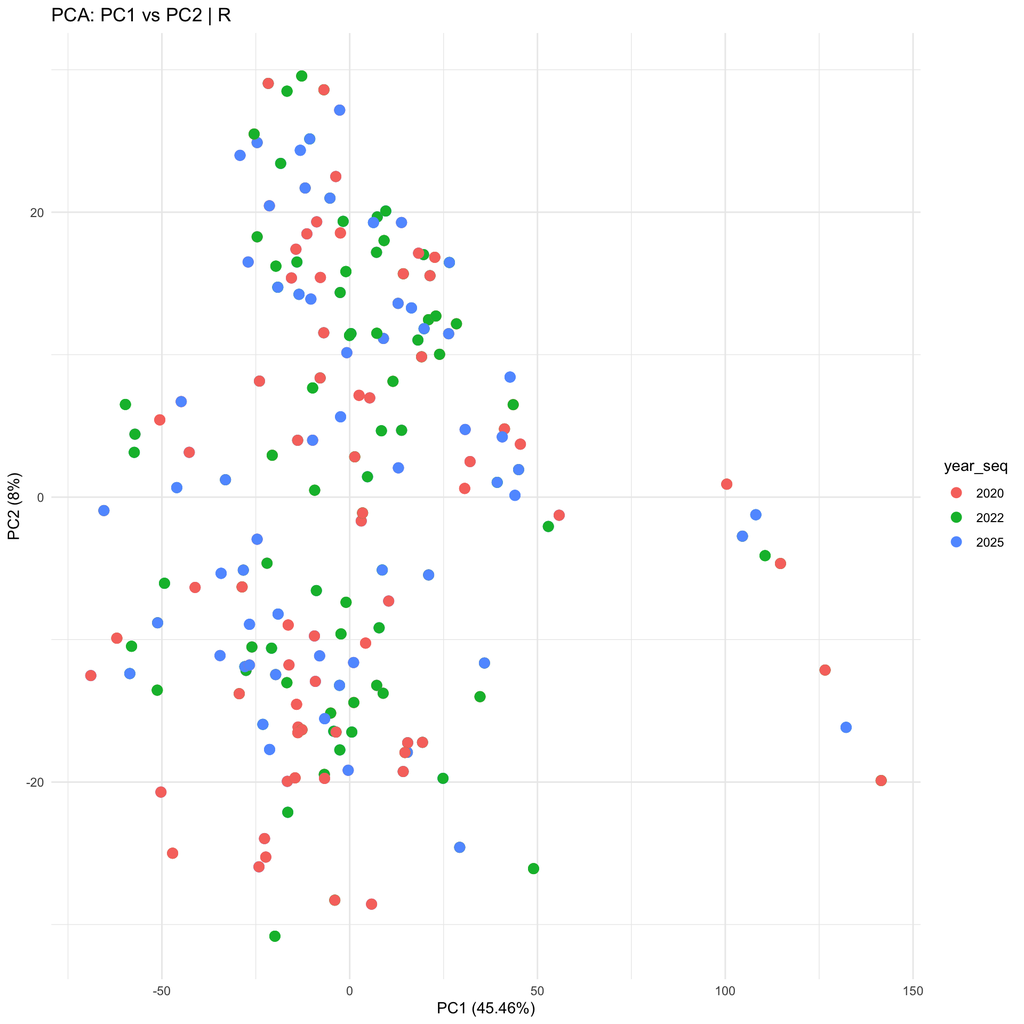

```r
p <- pca_plot(input = data,
              geno.pos = geno.pos,
              passport_file = passport_file,
              group_column = "year_seq",
              sampleID_column = "SampleName",
              col2use = "R")

p$PC1xPC2
```

The function draws a PCA using the total depth/intensities values of each marker x sample to identify batch effect between samples.

In this example, we did not detect evidence of batch effects, as samples did not cluster according to genotyping year. Therefore, we can proceed with standardization using the combined dataset.

If your dataset formed clear groups like the figure below referring to another dataset not covered in this tutorial:

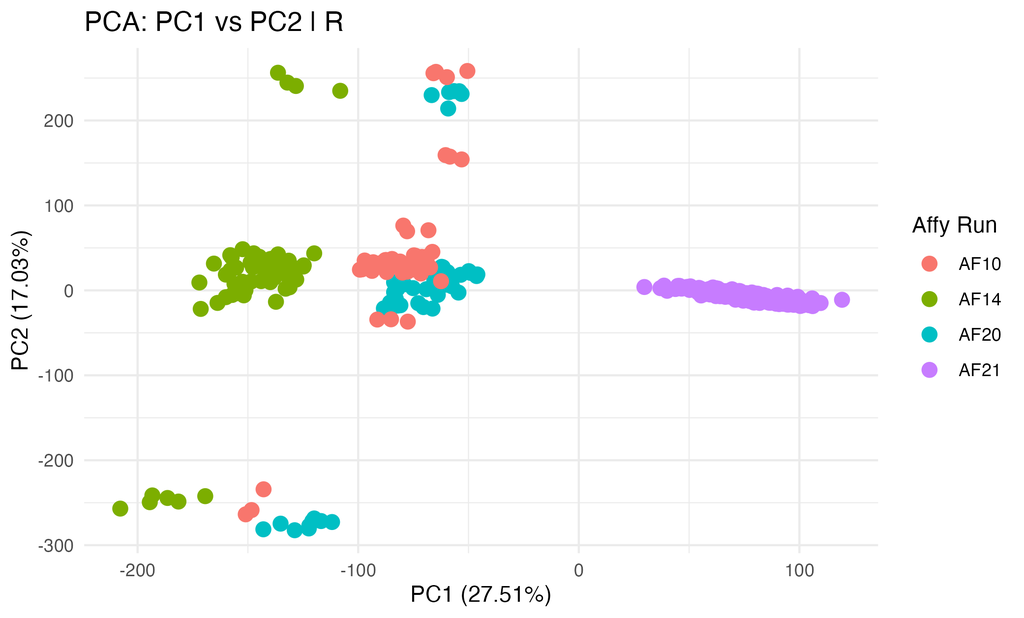

In this case, perform the standardization separately for each and merge the result using `merge_qploidy_datas` function.

You can also verify the effect of batches considering a single marker and all samples:

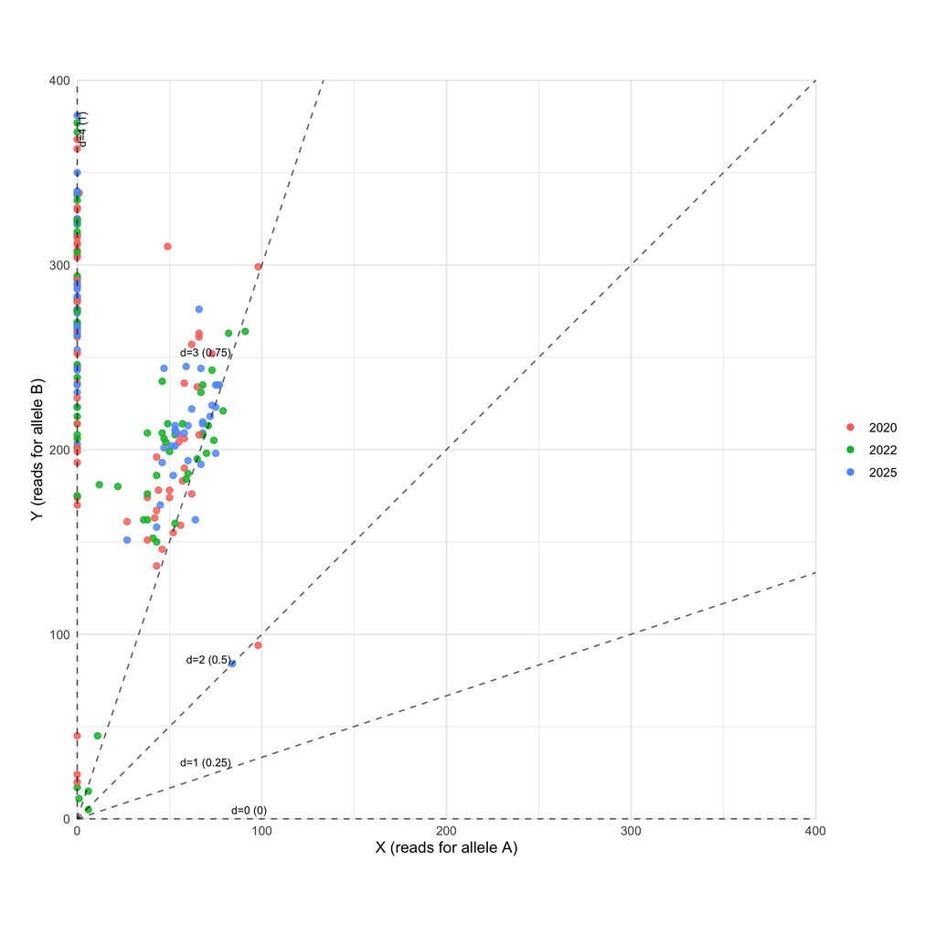

```r
plot_xy_with_ploidy_guides(data, ploidy = 4, marker = 1, samples = passport_file, palette = "auto")
```

Again, for this dataset, no difference is observed but here are some markers examples from another dataset that has batch effect:

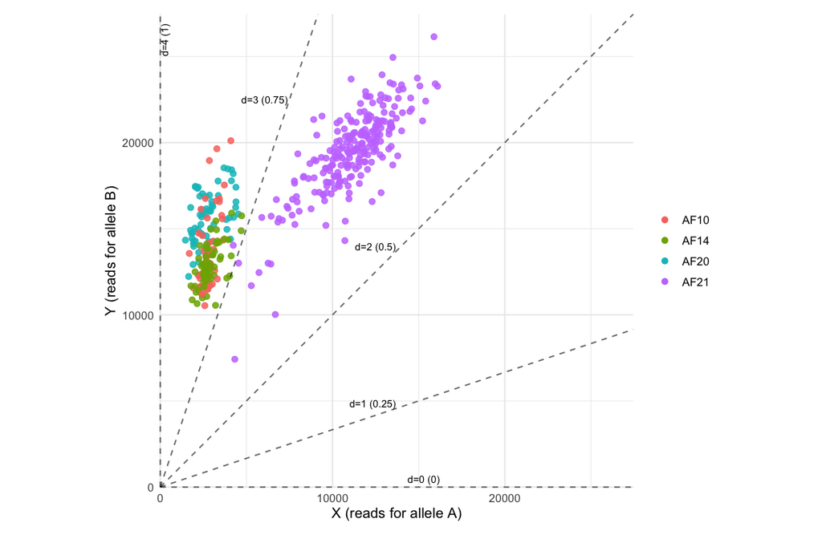

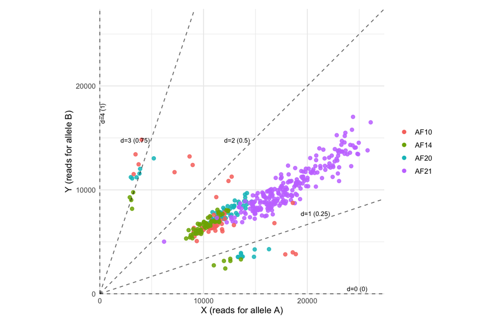

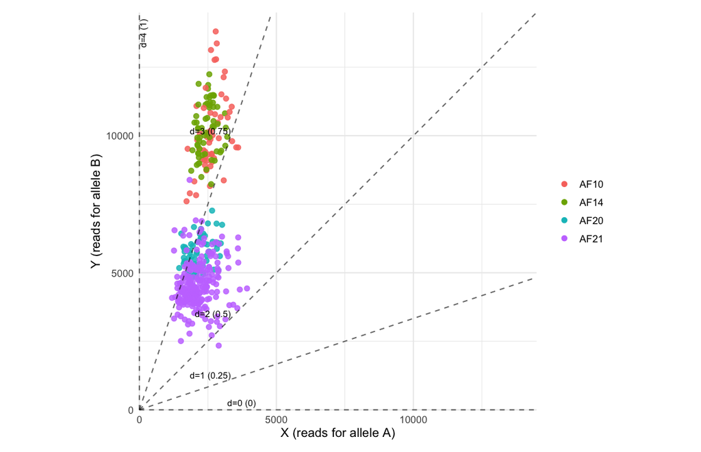

Dosage call methods such as `fitPoly`, `updog`, and `polyRAD` use these type of ratio distributions (one marker and all samples) to estimate each dosage cluster. If you have batch effect between your runs (as the figures above), they will also affect the quality of dosage call using these software. Therefore, you should conduct dosage/genotype call individually for each batch.

## 5.2 Initial screening for chromosome abnormalities (optional)

For some genotyping platforms, total read depth is consistent across samples. When this assumption holds for your dataset, deviations in a sample’s total depth relative to the population average can provide an initial indication of copy number variation.

You can rapidly screen for candidate samples using the function below:

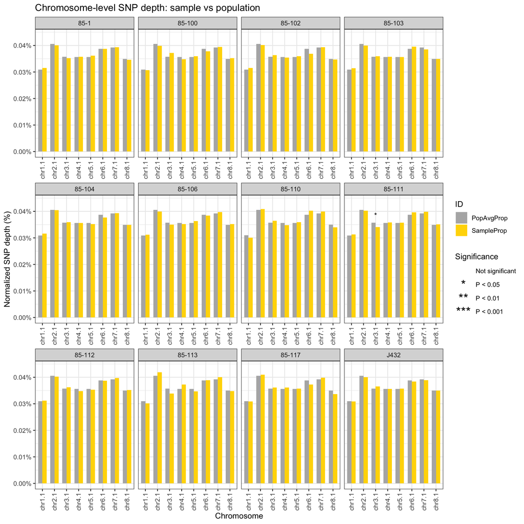

```r
chromosome_level_test_plot_qploidy(input = data,
                                   geno.pos = geno.pos,
                                   selected_samples = samples[1:12], # plot the first 12
                                   col2test = "R")
```

Before proceeding to the standardization step, consider removing abnormal chromosomes from your reference dataset (genos).

## 5.3 Overview of samples heterozygosity

```r
# interactive graphic if plotly package is installed
#p <- plot_heterozygosity(data, col2use = "ratio")
#p
```

# 6 Standardization

Standardization of markers raw read counts or intensity data is essential for reducing technical noise and improving the accuracy of ploidy estimation. Markers from diverse platforms have different characteristics, and standardization helps to make them comparable.

The function has several parameters that can be adjusted based on the characteristics of your dataset. You can access a description of all parameters in `?standardize`. Here we will focus only a few of them:

**Parameters:** - `genos`: This data.frame defines which samples are your reference for the standardization. If you have samples with known ploidy, filter this object to keep only them. You can use the command:

```r
# Demonstration code, not applied to current dataset
# known_tetraploids <- paste0("Sample",1:100)
# str(known_tetraploids)
# genos <- genos[which(genos$SampleName %in% known_tetraploids),]
```

If you are not sure about ploidy of at least 60 samples, just keep all them and define the most common ploidy as `ploidy.standardization`.

- `ploidy.standardization`: Sets the predominant ploidy for the dataset defined in the object `genos` (e.g., 2 for diploid, 4 for tetraploid). This guides clustering and normalization, and should match the known or most frequent ploidy in your samples for best results.
- `threshold.n.clusters`: Minimum number of genotype clusters required for a marker to be retained. The maximum is defined as the possible number of the dosages according to the ploidy defined on `ploidy.standardization` (ploidy + 1). Lower values requires imputation of dosage clusters for missing genotypes. The imputation is performed based on distance to other clusters, so it is recommended to have at least 3 clusters for a good imputation. If too many markers are filtered, relax this threshold (e.g., to 4 for tetraploids) to retain more markers with imputed clusters.

Other than the minimum number of clusters, the standardization step also applies some other filters:

- `threshold.missing.geno`: Maximum fraction of missing datapoints allowed per marker. Markers with a higher fraction will be removed.
- `threshold.missing.sample`: Maximum fraction of missing datapoints allowed per sample. Samples with a higher fraction will be removed.
- `min.depth`: Minimum read depth (R) threshold. Datapoints with R below this value will have their allele ratio set to missing and be excluded from BAF and Z-score computations.
- `max.depth`: Maximum read depth (R) threshold. Datapoints with R above this value will have their allele ratio set to missing and be excluded from BAF and Z-score computations.

Here is a summarized table with the arguments presented:

| Argument | Description |
| --- | --- |
| `genos` | Data.frame with samples and their dosage based on known or most common ploidy for standardization |
| `ploidy.standardization` | Predominant ploidy for the dataset used to call the dosages in the object `genos` |
| `threshold.n.clusters` | Minimum number of genotype dosage clusters required for a marker to be retained |
| `threshold.missing.geno` | Maximum fraction of missing datapoints allowed per marker |
| `threshold.missing.sample` | Maximum fraction of missing datapoints allowed per sample |
| `min.depth` | Minimum read depth (R) threshold |
| `max.depth` | Maximum read depth (R) threshold |

Explore more options with `?standardize`.

If your data comes from sequencing (and not hybridization), filtering by depth is important for quality control. To decide on the minimum and maximum of depth, you may want to take a quick look on the total depth distribution:

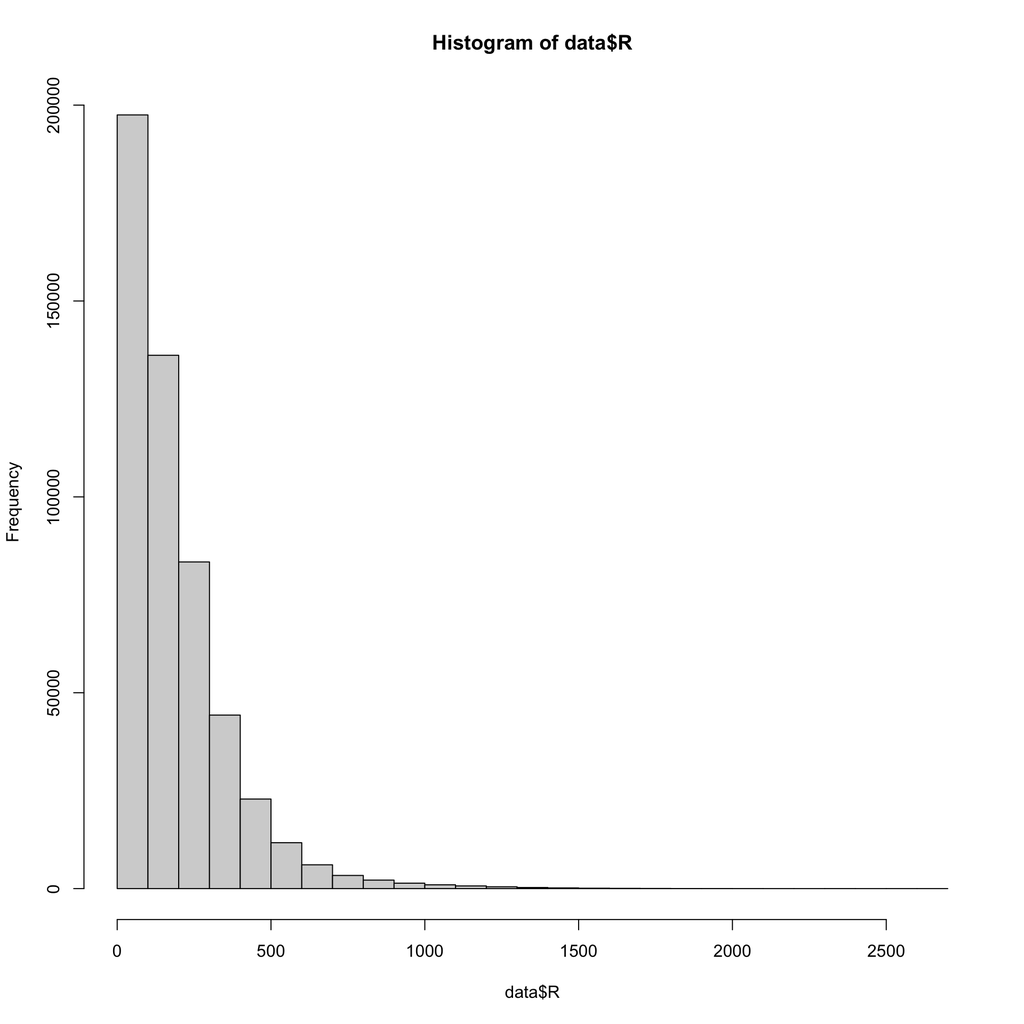

```r
hist(data$R)
```

```r
summary(data$R)
```

```
##    Min. 1st Qu.  Median    Mean 3rd Qu.    Max.
##     0.0    60.0   139.0   184.6   253.0  2635.0
```

The threshold should be around the mean but giving enough space for the variations:

```r
qploidy_standardization5 <- standardize(
  data = data,
  genos = genos,
  geno.pos = geno.pos,
  ploidy.standardization = 4, # Set to known or most frequent ploidy
  threshold.n.clusters = 5,   # Minimum clusters for marker retention
  threshold.missing.geno = 0.9,
  min.depth = 30,
  max.depth = 600,
  n.cores = 2,
  out_filename = "standardization.tsv.gz",
  verbose = TRUE
)

# Check filtering summary
qploidy_standardization5
```

```
## This is an object of class 'qploidy_standardization'
## --------------------------------------------------------------------
## Parameters
##
## 1 Standardization type:                             intensities
## 2 Ploidy:                                           4
## 3 Min # of heterozygous classes (clusters) present: 5
## 4 Max proportion of missing genotype by marker:     0.9
## 5 Max proportion of missing genotype by sample:     1
## 6 Min genotype probability:                         0.8
## 7 Min read depth (min.depth):                       30
## 8 Max read depth (max.depth):                       600
## --------------------------------------------------------------------
## Filters
##
## 1  # markers at raw data:                             2766  (100%)
## 2  # individuals in standardized data:                185   -
## 3  % datapoints filtered by low probability:          -     (0 %)
## 4  # datapoints filtered by depth (min/max):          84309 -
## 5  # samples filtered by missing data:                0     -
## 6  # markers filtered by missing data:                184   (6.65 %)
## 7  # markers filtered by min number of clusters:      2323  (83.98 %)
## 8  # markers filtered by lack of genomic information: 0     (0 %)
## 9  # markers remaining with estimated BAF:            259   (9.36 %)
## 10 # markers remaining with estimated z-score:        2664  (96.31 %)
```

The graphics below provides a visual explanation of how the standardization worked for 6 different markers:

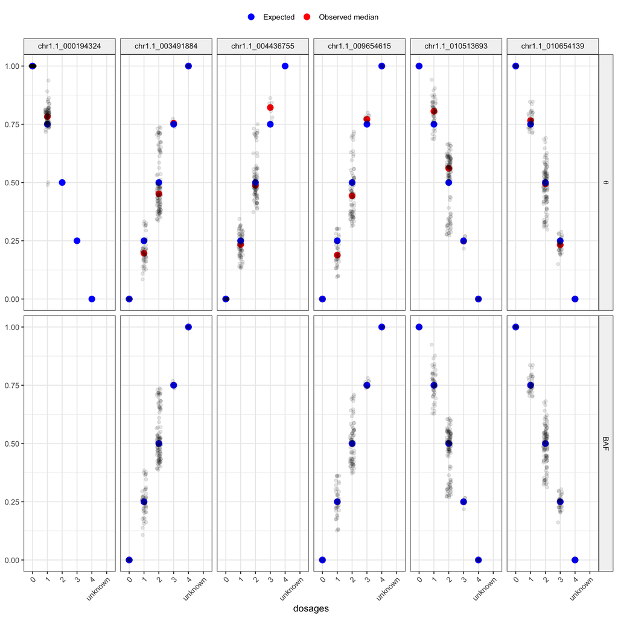

```r
plot_geno_by_marker(qploidy_standardization5, alpha = 0.1, marker = c(1,19,24,51,56,57))
```

Observe three different situations:

- The second, fourth, fifth and sixth markers: these markers had at least two samples included in the `genos` data.frame above (reference samples) for each dosage expected considering the ploidy defined at `ploidy.standardization = 4`. Therefore, standardization could be performed for all the dosages. It re-position the centroids of ratios dosage clusters (red dots) to the expected position (blue dots). After standardization every markers have dosage clusters centroids in same positions, making possible to combine them for sample, chromosome or chromosome region level BAF distribution evaluation.
- The first marker don’t have samples representing three of the dosages (2,3,4) and therefore the marker was filtered out and will not contain a BAF for downstream analysis (but kept for z-score).
- The third marker in the figure don’t have samples with dosage 4, missing a single cluster but also discarded given that the defined argument `threshold.n.clusters = 5` requires at least two samples for all five clusters.

**PS: We use B-allele frequency BAF terminology to refer to standardized ratios.**

If too many markers are filtered due to number of clusters, you relax the cluster threshold:

```r
qploidy_standardization <- standardize(
  data = data,
  genos = genos,
  geno.pos = geno.pos,
  ploidy.standardization = 4,
  threshold.n.clusters = 4,
  threshold.missing.geno = 0.9,
  min.depth = 30,
  max.depth = 600,
  n.cores = 2,
  out_filename = "standardization.tsv.gz",
  verbose = TRUE
)
qploidy_standardization
```

```
## This is an object of class 'qploidy_standardization'
## --------------------------------------------------------------------
## Parameters
##
## 1 Standardization type:                             intensities
## 2 Ploidy:                                           4
## 3 Min # of heterozygous classes (clusters) present: 4
## 4 Max proportion of missing genotype by marker:     0.9
## 5 Max proportion of missing genotype by sample:     1
## 6 Min genotype probability:                         0.8
## 7 Min read depth (min.depth):                       30
## 8 Max read depth (max.depth):                       600
## --------------------------------------------------------------------
## Filters
##
## 1  # markers at raw data:                             2766  (100%)
## 2  # individuals in standardized data:                185   -
## 3  % datapoints filtered by low probability:          -     (0 %)
## 4  # datapoints filtered by depth (min/max):          84309 -
## 5  # samples filtered by missing data:                0     -
## 6  # markers filtered by missing data:                184   (6.65 %)
## 7  # markers filtered by min number of clusters:      1801  (65.11 %)
## 8  # markers filtered by lack of genomic information: 0     (0 %)
## 9  # markers remaining with estimated BAF:            781   (28.24 %)
## 10 # markers remaining with estimated z-score:        2664  (96.31 %)
```

In this case, Qploidy inputs the position of the missing cluster based on the mean distance between the existing ones making possible to perform the standardization. In our visual example, the third marker is kept after the change:

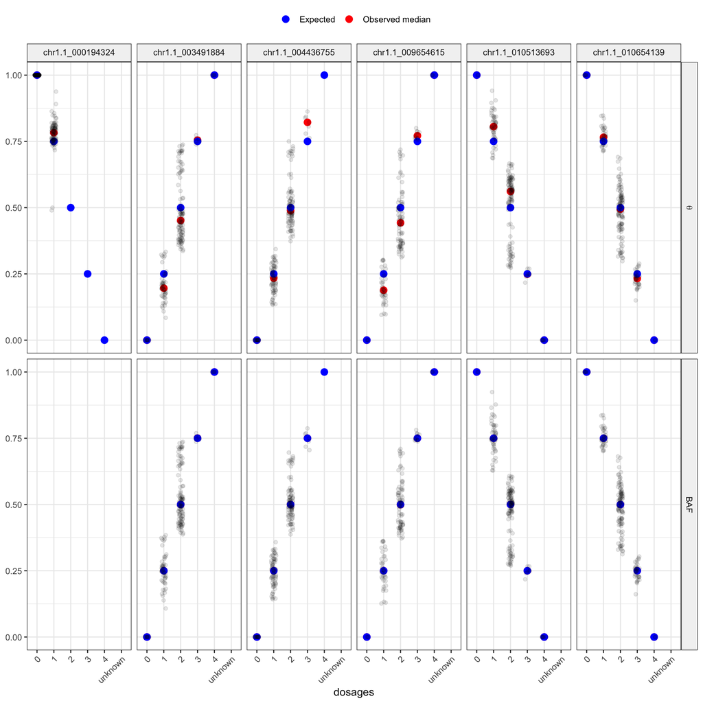

```r
plot_geno_by_marker(qploidy_standardization, alpha = 0.1, marker = c(1,19,24,51,56,57))
```

The function also generates the Qploidy file `standardization.tsv.gz` that you can reload in another session to recover the `qploidy_standardization` object:

```r
qploidy_standardization <- read_qploidy_standardization("standardization.tsv.gz")
```

This file can also be uploaded to `GenoBrew` app for results curation. See section `Interactive curation of results`.

# 7 Quality Assessment and Visualization

Visualize the effect of standardization for each sample and explore BAF and Z-score distributions:

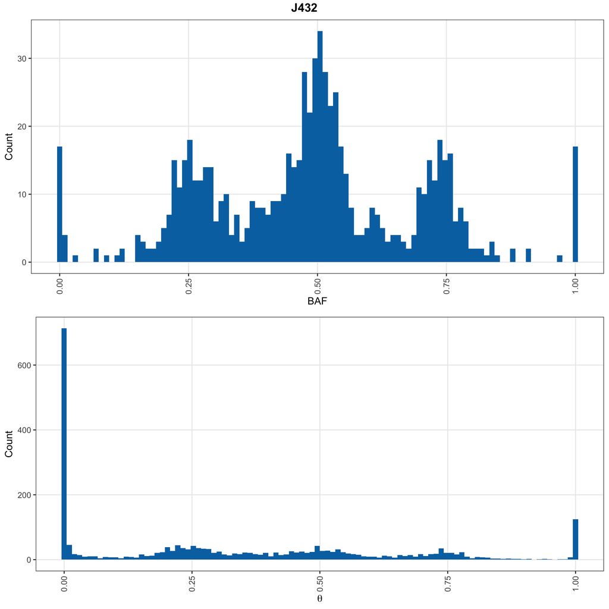

```r
plot_qploidy_standardization(x = qploidy_standardization,
                             sample = "J432",
                             type = c("Ratio_hist_overall", "BAF_hist_overall"))
```

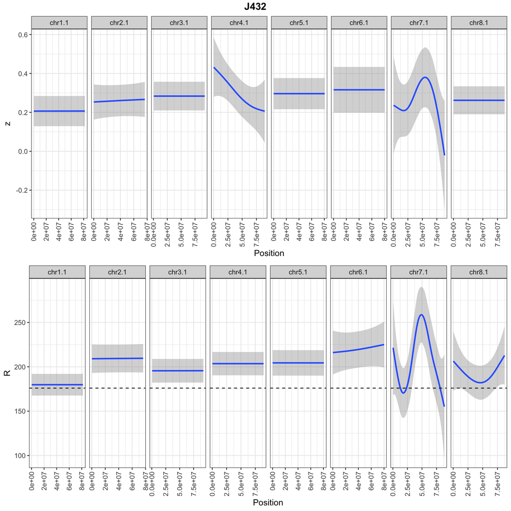

```r
plot_qploidy_standardization(x = qploidy_standardization,
                             sample = "J432",
                             type = c("zscore", "R"))
```

See `?plot_qploidy_standardization` for more plot types.

## 7.1 Chromosome-level screening for abnormalities based on Z-score (optional)

You can use the same quick check we used before on the raw total depth (R) with the standardized z-scores. This is useful to identify samples with potential aneuploidies or large CNVs before running the HMM, and also to select samples with known ploidy to guide the BAF model selection.

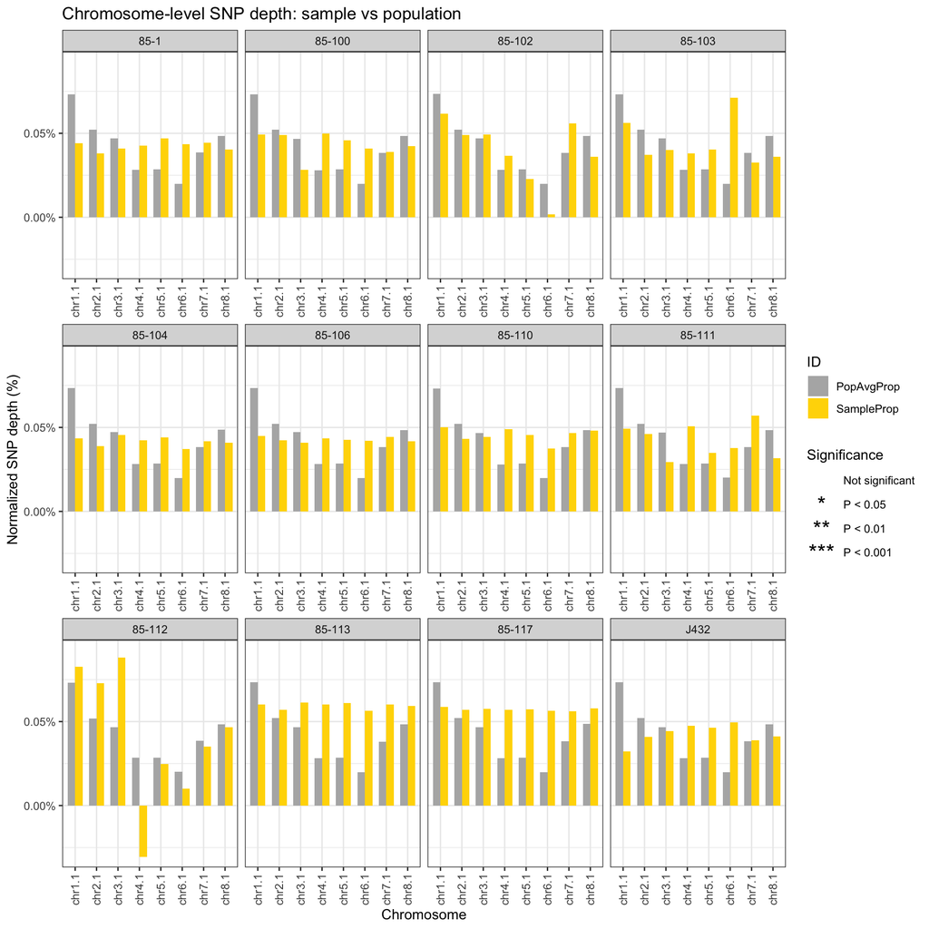

```r
chromosome_level_test_plot_qploidy(input = qploidy_standardization,
                                   selected_samples = samples[1:12],
                                   col2test = "z")
```

# 8 BAF Model Selection

Select the best BAF model for a sample. The approach implemented here for this step is based on [`nQuack`](https://github.com/mgaynor1/nQuack) methods. It tests different statistical distribution mixture models fitting for each tested ploidy on the BAF distributions and selects the best based on BIC. There are two ways of performing it, one “quick and dirt” based on comparing parameters in a grid and another using `nQuack` EM functions:

- EM approach BAF model selection: has a robust EM algorithm able to return tailored parameters for the selected distribution to users
- Grid approach BAF model selection: does not use an EM algorithm but a grid of parameters to be tested, which is less time- and computationally demanding but may not provide the best parameters for this step. The results from this step are initial parameters for the HMM, which will be further optimized by the EM algorithm implemented in the HMM.

This current tutorial apply the “grid approach”. Check tutorial Qploidy2 and nQuack integration for running the EM approach using nQuack.

This step helps determine the most likely ploidy and mixture model parameters for BAF. The selected approach and model will be used in the `Qploidy2` HMM for copy number estimation.

You can select a sample with known ploidy (e.g., from the previous step) to guide the model selection, or test multiple samples and compare results.

## 8.1 Applying to raw data

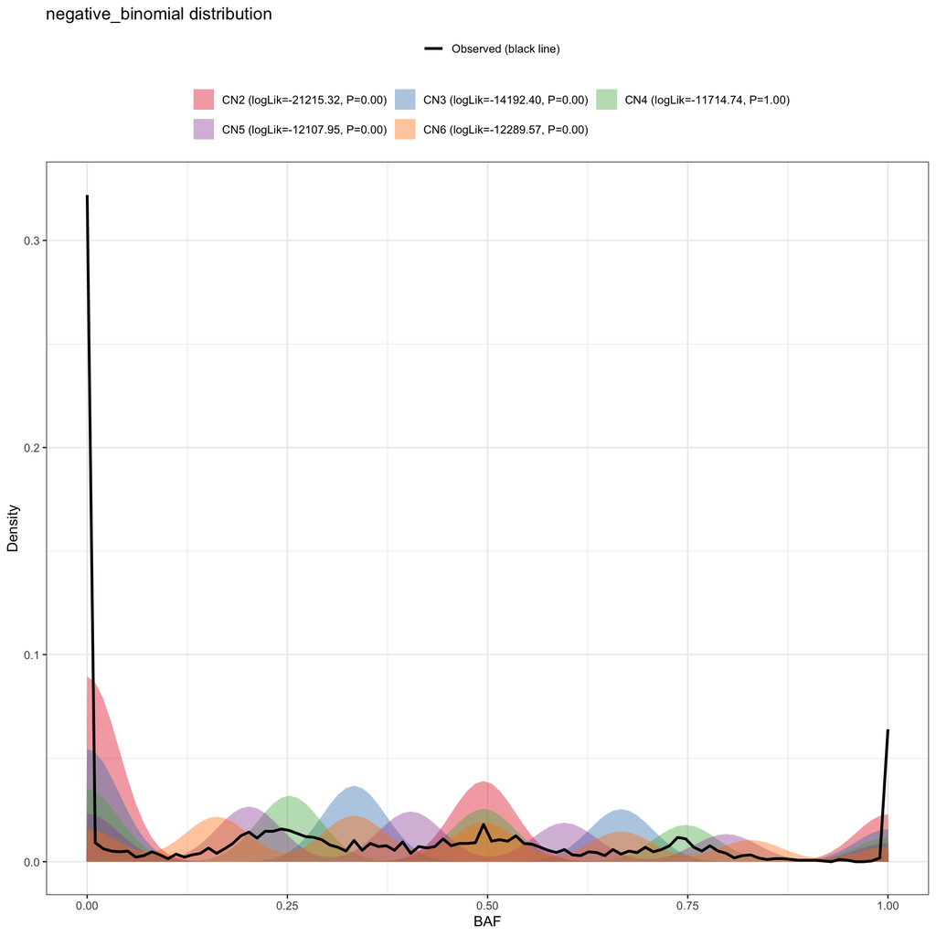

```r
sample_ratios <- data$ratio[data$SampleName == "J432"]
selected_model_raw <- select_best_baf_model(baf_vec = sample_ratios,
                                            cn_grid= c(2,3,4,5,6),
                                            bw = c(0.01, 0.02, 0.04), # Default values
                                            plot = TRUE)

selected_model_raw$plot
```

```r
head(selected_model_raw$grid_results)
```

|  | dist | bw | add_uniform | uniform_weight | best_cn | logLik | prob | BIC |
| --- | --- | --- | --- | --- | --- | --- | --- | --- |
| 9 | negative_binomial | 0.04 | FALSE | 0 | 4 | -11714.74 | 1 | 23437.38 |
| 8 | beta_binomial | 0.04 | FALSE | 0 | 4 | -12190.86 | 1 | 24389.62 |
| 7 | gaussian | 0.04 | FALSE | 0 | 4 | -12606.52 | 1 | 25220.95 |
| 6 | negative_binomial | 0.02 | FALSE | 0 | 6 | -14394.58 | 1 | 28797.08 |
| 5 | beta_binomial | 0.02 | FALSE | 0 | 6 | -15019.23 | 1 | 30046.37 |
| 4 | gaussian | 0.02 | FALSE | 0 | 6 | -15969.80 | 1 | 31947.51 |

## 8.2 Applying to standardized data

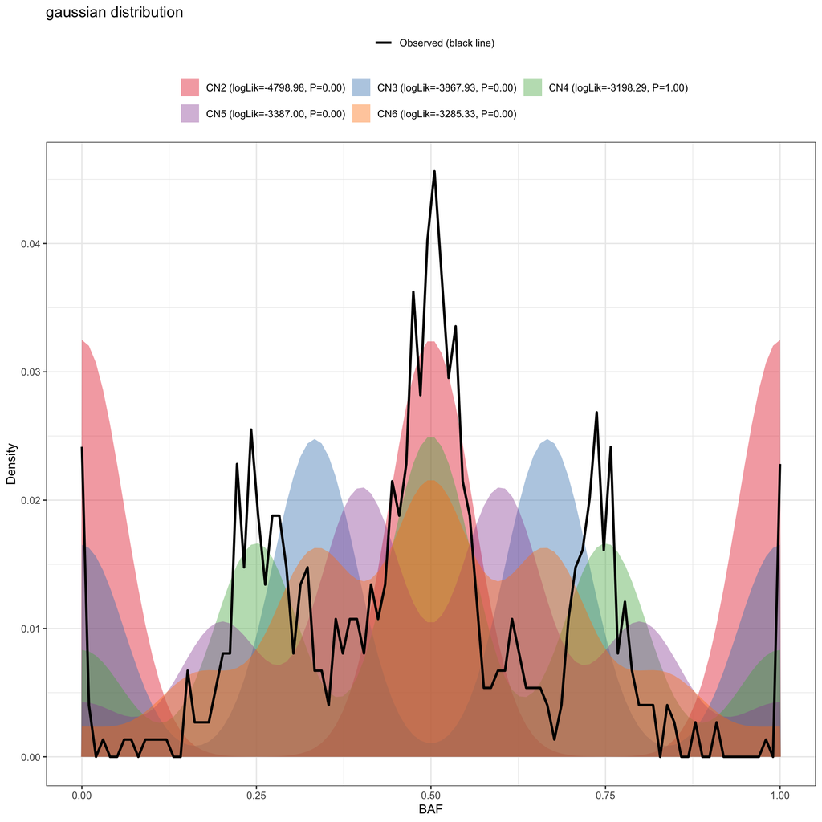

```r
selected_model <- select_best_baf_model(qploidy_standardization = qploidy_standardization,
                                        sample = "J432",
                                        cn_grid= c(2,3,4,5,6),
                                        bw = c(0.02, 0.04, 0.06, 0.08, 0.1),
                                        plot = TRUE)

selected_model$plot
```

```r
head(selected_model$grid_results)
```

|  | dist | bw | add_uniform | uniform_weight | best_cn | logLik | prob | BIC |
| --- | --- | --- | --- | --- | --- | --- | --- | --- |
| 7 | gaussian | 0.06 | FALSE | 0 | 4 | -3198.295 | 1.0000000 | 6403.203 |
| 10 | gaussian | 0.08 | FALSE | 0 | 4 | -3251.261 | 1.0000000 | 6509.135 |
| 8 | beta_binomial | 0.06 | FALSE | 0 | 4 | -3254.552 | 1.0000000 | 6515.717 |
| 4 | gaussian | 0.04 | FALSE | 0 | 4 | -3280.574 | 1.0000000 | 6567.761 |
| 13 | gaussian | 0.10 | FALSE | 0 | 6 | -3287.065 | 0.9999944 | 6580.743 |
| 9 | negative_binomial | 0.06 | FALSE | 0 | 4 | -3303.504 | 1.0000000 | 6613.622 |

Using standardized model, the four best models returned ploidy 4 proving to be more stable than without standardization.

# 9 HMM Copy Number Estimation (Single Sample)

Estimate copy number for a sample using a Hidden Markov Model. This step provides a robust approach that integrates raw or standardized ratios (BAF) and total depth (Z-score) information across genomic regions to infer CNV segments. Find all parameters description in `?hmm_estimate_CN`.

```r
res <- hmm_estimate_CN(qploidy_standarize_result = qploidy_standardization,
                       sample_id ="J432",
                       cn_grid =  c(2,3,4,5,6))

# View results
res
```

```
## hmm_CN result
##   Copy-number grid: 2, 3, 4, 5, 6
##   Expected ploidy: 4
##   Minimum SNPs per window: 32
##   Initial state probabilities (pi0): 0.125, 0.125, 0.5, 0.125, 0.125
##   Estimated z means per CN: -0.253, -0.002, 0.245, 0.5, 0.751
##   Estimated z mean: 0.2490823
##   Estimated z sigma: 0.138
##   BAF Emission distribution: gaussian
##   Final log-likelihood: 0
##   Range of CN_call (window-level): 4 - 4
```

Not that the HMM multipoint approach consider the marker position order based on the reference genome used. Therefore, changing the reference genome may change the results.

**Warning**: Avoid to use unlikely copy numbers for your specie to decrease the number of tested scenarios.

`Qploidy2` has different ways to visualize the estimated karyotype:

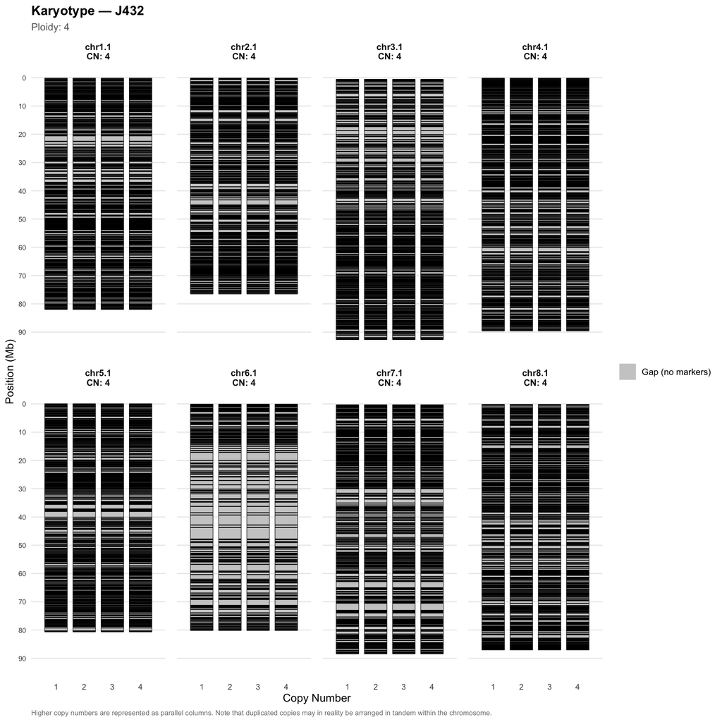

```r
plot_karyotype(res, sample_name = "J432", nrow = 2)
```

You can add color by the CN call final likelihood:

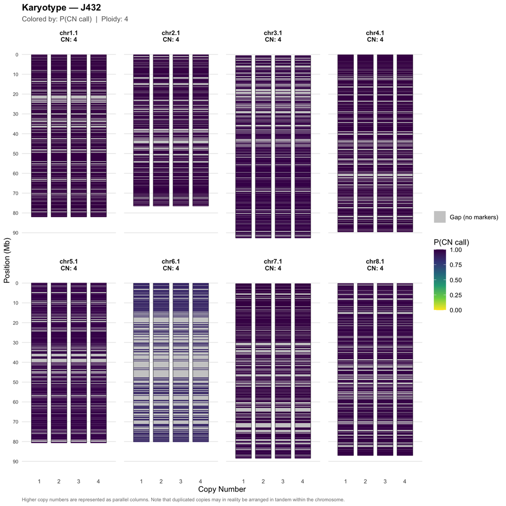

```r
plot_karyotype(res, sample_name = "J432", nrow = 2, color_by = "post_max_CN")
```

The color show how confident the model was on calling the CN for each of the markers based on the combination of R/z-score and ratio/BAF.

You can also add color by the BAF weight:

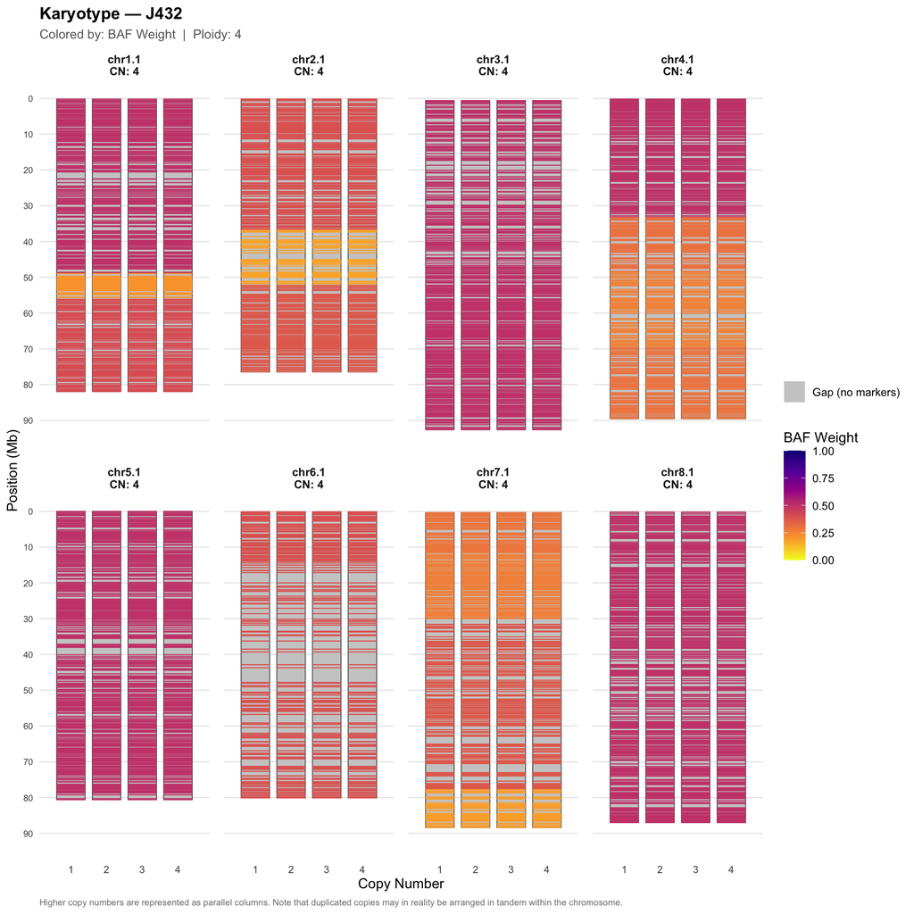

```r
plot_karyotype(res, sample_name = "J432", nrow = 2, color_by = "w_baf")
```

This metric shows if the CN for the window was inferred based on the BAF/ratio given the presence of heterozygous genotypes within it, or if it was just based on the total depth/z-score given the lack of heterozygosity. The most confident estimations are the ones that are based on both BAF/ratio and R/z-score - they have BAF weight of 0.5 (and 0.5 for z-score weight).

The function `plot_cn_track` provides a detailed diagnostic of the process:

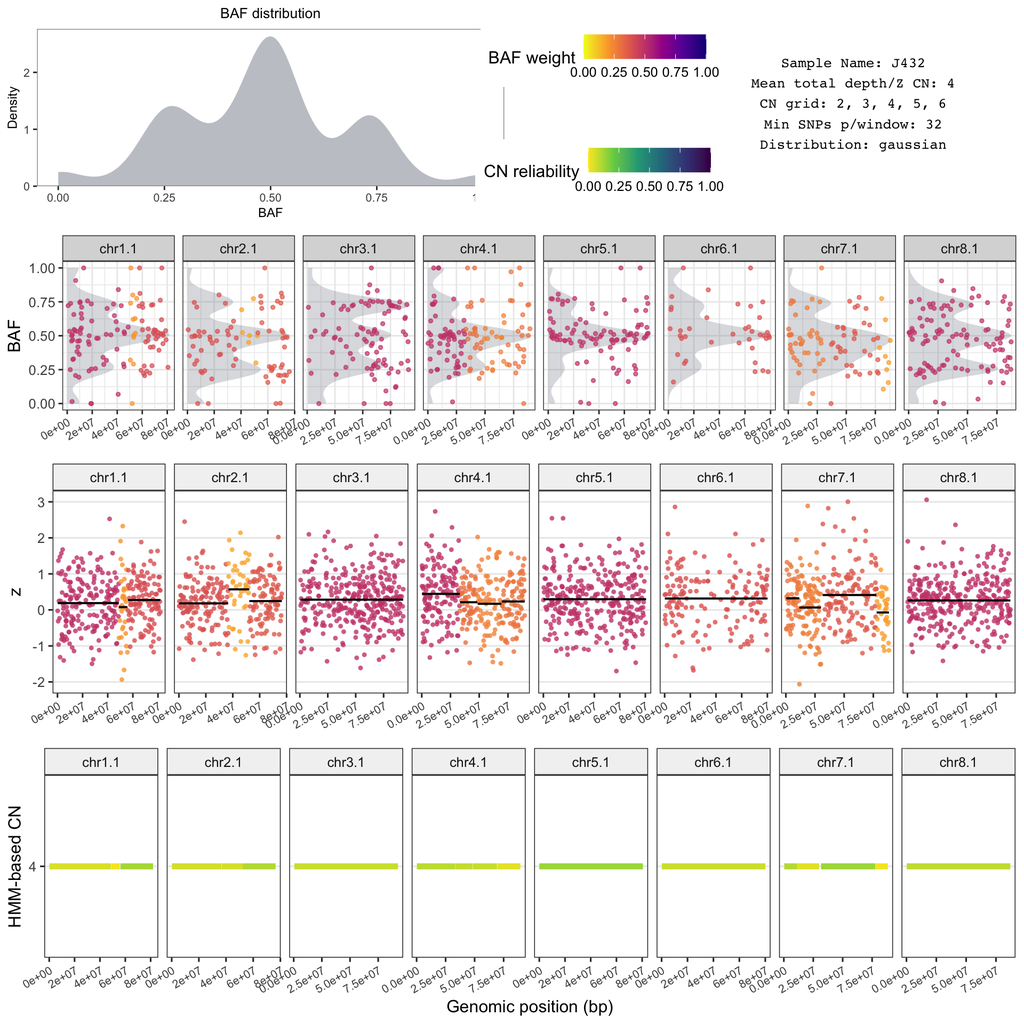

```r
p <- plot_cn_track(hmm_CN = res,
                   data = data,
                   geno.pos = geno.pos,
                   sample_id = "J432",
                   show_window_lines = FALSE,
                   z_by_mean = TRUE)

# All panels together
p$arranged
```

The CN segments in the bottom track are coloured by `CN_reliability`, a joint confidence score calculated as `post_max × normalized_w_baf`. It summarises both the HMM’s certainty about the called CN state and whether the call was supported by BAF evidence:

Despite not having the same peak resolution as the standardized data, the HMM was robust enough to retun correct result (CN 4) for all chromosomes. The standardization will be more critical for more complex scenarios, such as messy ratios, and/or presence of loss or gain of chromosomes. We have some example further in this tutorial.

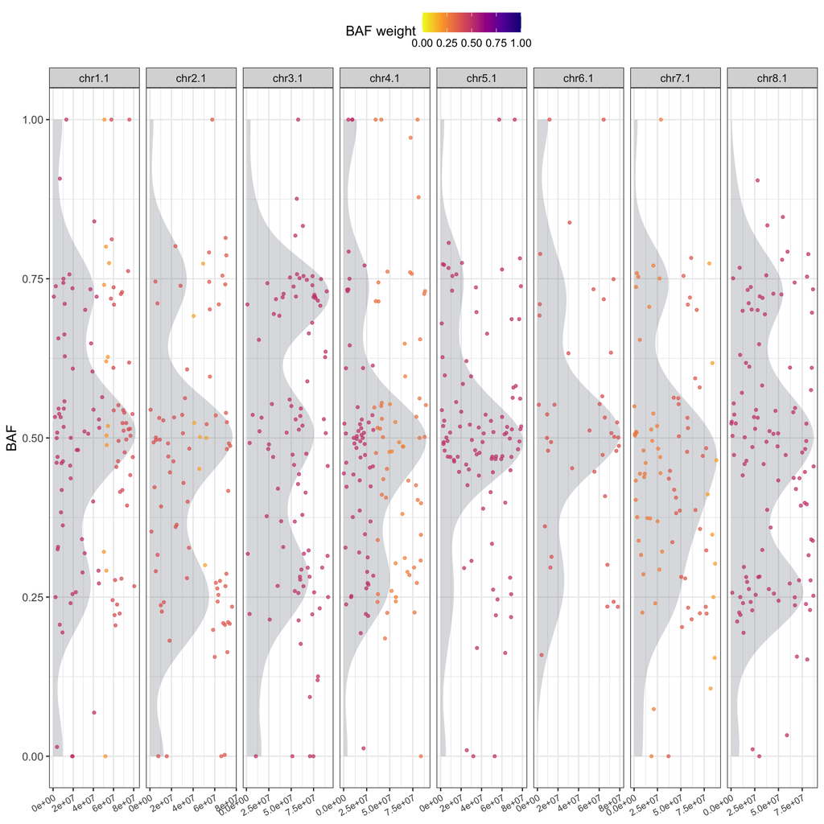

```r
# Individual panels
p$baf
```

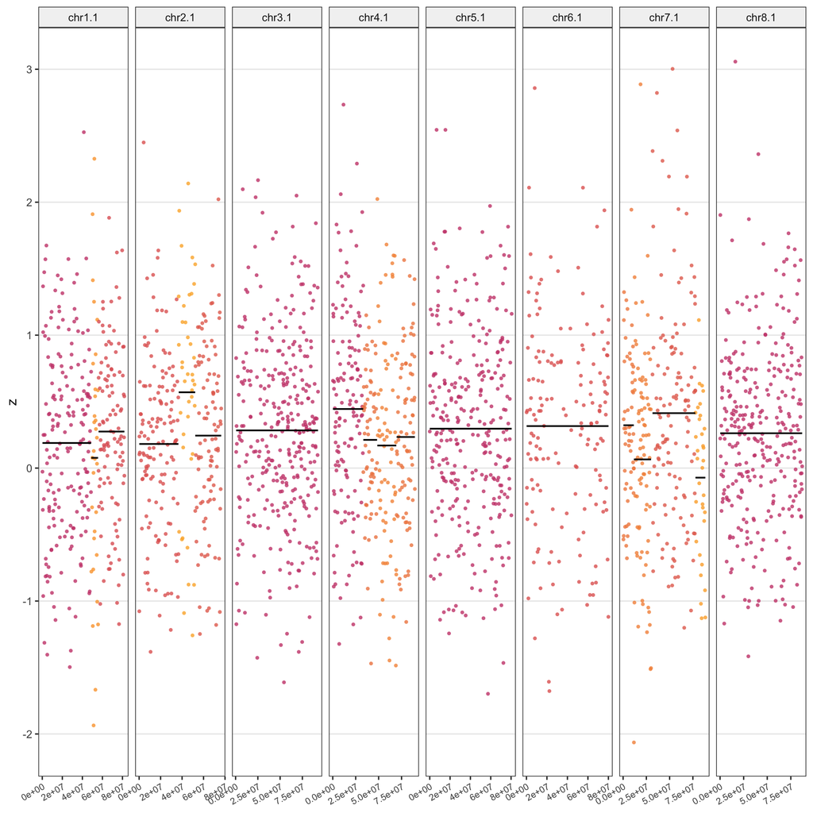

```r
p$z
```

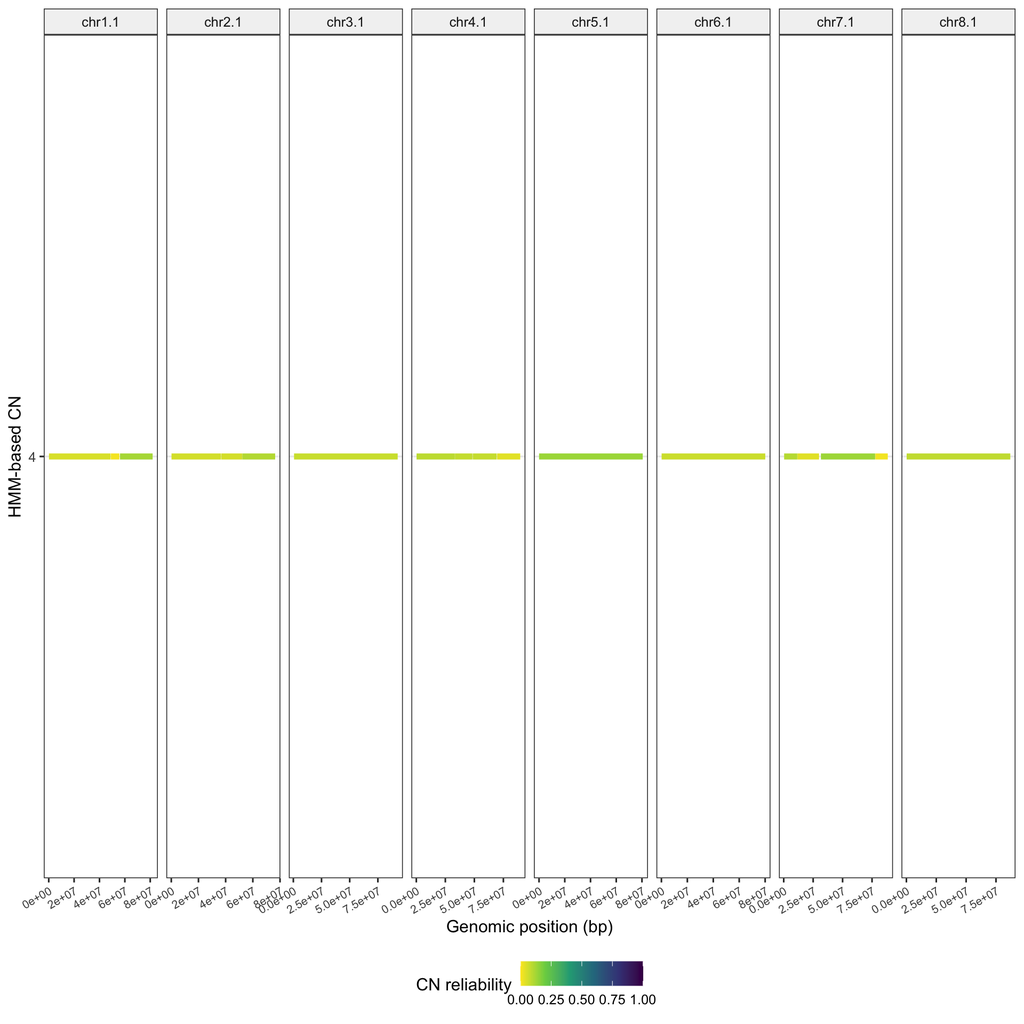

```r
p$cn
```

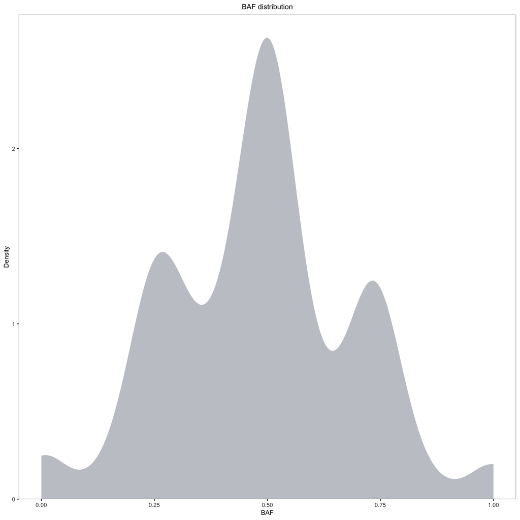

```r
p$baf_dist
```

See the results in a `data.frame` format:

```r
head(res$by_window)
```

|  | Sample | Chr | WindowID | Start | End | n_snps | n_het | z | w_baf | CN_call | CN_reliability | post_max | post_CN2 | post_CN3 | post_CN4 | post_CN5 | post_CN6 |
| --- | --- | --- | --- | --- | --- | --- | --- | --- | --- | --- | --- | --- | --- | --- | --- | --- | --- |
| 1 | J432 | chr1.1 | 1 | 194324 | 48745063 | 187 | 58 | 0.18870556 | 0.5000000 | 4 | 0.05209680 | 0.9998337 | 1.916541e-13 | 1.662635e-04 | 0.9998337 | 3.467269e-08 | 4.625177e-13 |
| 2 | J432 | chr1.1 | 2 | 48967392 | 55663565 | 32 | 10 | 0.07709891 | 0.2083333 | 4 | 0.01166861 | 0.9998124 | 4.761895e-08 | 1.856760e-04 | 0.9998124 | 1.874836e-06 | 3.139970e-11 |
| 3 | J432 | chr1.1 | 3 | 56166196 | 81910582 | 110 | 38 | 0.27483097 | 0.4061164 | 4 | 0.12096947 | 0.9996359 | 7.869092e-08 | 2.084686e-04 | 0.9996359 | 1.538264e-04 | 1.752332e-06 |
| 4 | J432 | chr2.1 | 1 | 171719 | 36610401 | 141 | 36 | 0.18142219 | 0.3952847 | 4 | 0.05877274 | 0.9953211 | 6.692247e-18 | 4.613589e-08 | 0.9953211 | 4.678881e-03 | 2.229916e-12 |
| 5 | J432 | chr2.1 | 2 | 36858792 | 52243977 | 41 | 7 | 0.57025992 | 0.1743042 | 4 | 0.05729600 | 0.9944705 | 1.471334e-13 | 6.512216e-08 | 0.9944705 | 5.519233e-03 | 1.017109e-05 |
| 6 | J432 | chr2.1 | 3 | 52278775 | 76438134 | 100 | 32 | 0.24426828 | 0.3726780 | 4 | 0.10408438 | 0.9943714 | 7.452351e-08 | 5.920681e-05 | 0.9943714 | 5.565006e-03 | 4.319640e-06 |

```r
head(res$by_marker)
```

|  | Chr | .__w__ | MarkerName | SampleName | X | Y | R | ratio | geno | baf | z | Position | outlier | w_baf | CN_call | post_max | CN_reliability |
| --- | --- | --- | --- | --- | --- | --- | --- | --- | --- | --- | --- | --- | --- | --- | --- | --- | --- |
| 1 | chr1.1 | 1 | chr1.1_000194324 | J432 | 0 | 264 | 264 | 1.0000000 | 0 | NA | -0.02723827 | 194324 | FALSE | 0.5 | 4 | 0.9998337 | 0.0520968 |
| 2 | chr1.1 | 1 | chr1.1_000532584 | J432 | 128 | 0 | 128 | 0.0000000 | 0 | NA | -0.31432806 | 532584 | FALSE | 0.5 | 4 | 0.9998337 | 0.0520968 |
| 3 | chr1.1 | 1 | chr1.1_000735393 | J432 | 29 | 82 | 111 | 0.7387387 | 1 | 0.7219162 | 1.36730223 | 735393 | FALSE | 0.5 | 4 | 0.9998337 | 0.0520968 |
| 4 | chr1.1 | 1 | chr1.1_000837330 | J432 | 196 | 46 | 242 | 0.1900826 | 1 | NA | 1.02226496 | 837330 | FALSE | 0.5 | 4 | 0.9998337 | 0.0520968 |
| 5 | chr1.1 | 1 | chr1.1_000915014 | J432 | 37 | 0 | 37 | 0.0000000 | 0 | NA | -0.96249066 | 915014 | FALSE | 0.5 | 4 | 0.9998337 | 0.0520968 |
| 6 | chr1.1 | 1 | chr1.1_001169609 | J432 | 328 | 0 | 328 | 0.0000000 | 0 | NA | 0.24921519 | 1169609 | FALSE | 0.5 | 4 | 0.9998337 | 0.0520968 |

```r
head(res$params)
```

```
## $cn_grid
## [1] 2 3 4 5 6
##
## $distribution
## [1] "gaussian"
##
## $mu
##            2            3            4            5            6
## -0.252933002 -0.001925337  0.244513341  0.500211425  0.751340522
##
## $sigma
## [1] 0.1382905
##
## $A
##       [,1]  [,2]         [,3]         [,4]         [,5]
## [1,] 1e-12 1e-12 1.000000e-12 9.993328e-01 6.672283e-04
## [2,] 1e-12 1e-12 1.000000e-12 9.993035e-01 6.964530e-04
## [3,] 1e-12 1e-12 1.000000e+00 1.762119e-08 1.000000e-12
## [4,] 1e-12 1e-12 9.999762e-01 2.378487e-05 1.000000e-12
## [5,] 1e-12 1e-12 1.000000e+00 2.132487e-12 1.012771e-12
##
## $pi0
## [1] 0.125 0.125 0.500 0.125 0.125
```

# 10 HMM Copy Number Estimation (Multiple Samples)

Run HMM for all samples in parallel. The model will be selected internally using `select_best_baf_model`; you just need to define the grids (`bw`, `add_uniform_grid`, and `uniform_weight_grid`) according to what you observed when running it on a single sample.

**Note**: Running HMM for many samples can be computationally intensive. Adjust `n_cores` based on your resources and dataset size.

```r
multi_esti <- hmm_estimate_CN_multi(qploidy_standarize_result = qploidy_standardization,
                                    sample_ids = "all",
                                    n_cores = 2,
                                    cn_grid =  c(2,3,4,5,6))
```

Visualize summary of CNV for multiple samples:

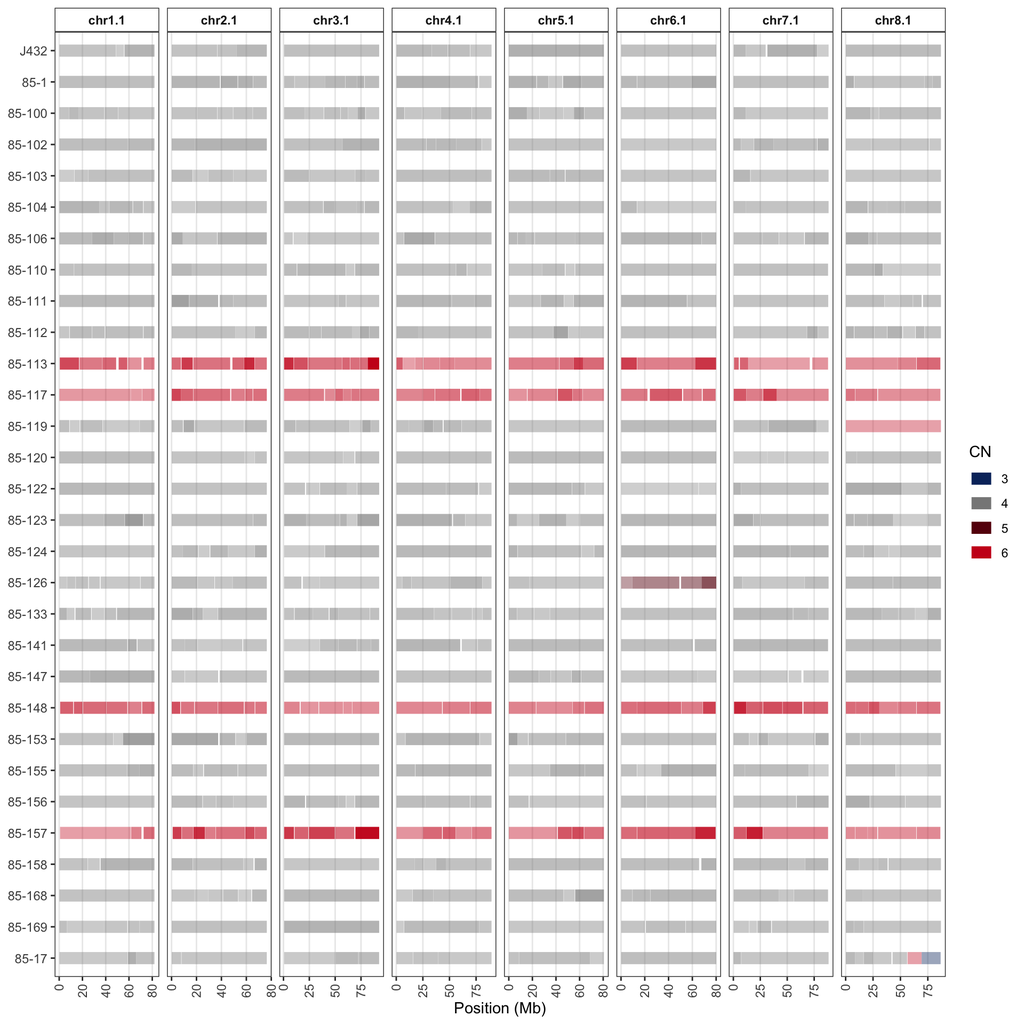

```r
compare_cn_track(hmm_CN = multi_esti,
                 samples_to_plot = samples[1:30],
                 facet_ncol = 8)
```

# 11 Filter by CN call according to quality metrics

`filter_hmm_CN()` masks CN calls that do not meet user-defined quality thresholds by replacing `CN_call`, `post_max`, `CN_reliability`, and all `post_CN*` posteriors with `NA`. Masked windows are treated as missing by all downstream plotting and export functions.

The two most commonly used thresholds are:

- `min_CN_reliability` — joint confidence combining HMM posterior probability and BAF weight. A value of `0` means no BAF evidence at all; `1` means full BAF support with a confident HMM call. Windows supported only by z-score (e.g., all-homozygous chromosomes) cannot exceed `z_no_baf_scale × post_max` in reliability (default cap = `0.25 × post_max`).
- `min_post_max` — the raw HMM posterior probability for the called CN state, regardless of BAF support. Useful when you want to retain z-score-only calls but still discard low-confidence HMM calls.

```r
multi_esti_filtered <- filter_hmm_CN(multi_esti,
                                     min_CN_reliability = 0.05,
                                     min_post_max = 0.25)
```

# 12 Summarized plots and tables

After curating individual sample results you can get a high-level overview of the entire population using two complementary tools.

`count_types()` classifies every sample as **euploid** (all chromosomes match the sample-level copy number), **aneuploid** (one or more chromosomes carry a different but uniform CN — whole-chromosome gain or loss), or **segmental** (at least one chromosome has windows with mixed CN, indicating a partial chromosomal change). It prints a summary table to the console and returns a named list of sample-ID vectors that you can use for downstream filtering:

```r
types_df <- count_types(multi_esti)
types_df
```

```
##
## Sample classification summary
## ====================================================
##   4x  (n = 175)
##     4x - euploid            147
##     4x - aneuploid          15
##     4x - segmental          13
##   5x  (n = 1)
##     5x - euploid            1
##   6x  (n = 9)
##     6x - euploid            9
## ----------------------------------------------------
##   Total euploid              157
##   Total aneuploid            15
##   Total segmental aneuploidy 13
##   Grand total                185
## ====================================================
```

```r
str(types_df)
```

```
## List of 5
##  $ euploid  : chr [1:157] "85-1" "85-100" "85-102" "85-103" ...
##  $ aneuploid: chr [1:15] "85-119" "85-126" "85-182" "85-192" ...
##  $ segmental: chr [1:13] "85-17" "85-185" "85-203" "85-210" ...
##  $ by_cn    :List of 3
##   ..$ 4x:List of 3
##   .. ..$ euploid  : chr [1:147] "85-1" "85-100" "85-102" "85-103" ...
##   .. ..$ aneuploid: chr [1:15] "85-119" "85-126" "85-182" "85-192" ...
##   .. ..$ segmental: chr [1:13] "85-17" "85-185" "85-203" "85-210" ...
##   ..$ 5x:List of 3
##   .. ..$ euploid  : chr "85-177"
##   .. ..$ aneuploid: chr(0)
##   .. ..$ segmental: chr(0)
##   ..$ 6x:List of 3
##   .. ..$ euploid  : chr [1:9] "85-113" "85-117" "85-148" "85-157" ...
##   .. ..$ aneuploid: chr(0)
##   .. ..$ segmental: chr(0)
##  $ .summary : tibble [185 × 5] (S3: tbl_df/tbl/data.frame)
##   ..$ Sample       : chr [1:185] "85-1" "85-100" "85-102" "85-103" ...
##   ..$ sample_cn    : int [1:185] 4 4 4 4 4 4 4 4 4 6 ...
##   ..$ has_mixed    : logi [1:185] FALSE FALSE FALSE FALSE FALSE FALSE ...
##   ..$ has_aneuploid: logi [1:185] FALSE FALSE FALSE FALSE FALSE FALSE ...
##   ..$ sample_type  : chr [1:185] "euploid" "euploid" "euploid" "euploid" ...
##  - attr(*, "class")= chr "count_types"
```

```r
types_df_filtered <- count_types(multi_esti_filtered)
types_df_filtered
```

```
##
## Sample classification summary
## ====================================================
##   4x  (n = 175)
##     4x - euploid            159
##     4x - aneuploid          13
##     4x - segmental          3
##   5x  (n = 1)
##     5x - euploid            1
##   6x  (n = 9)
##     6x - euploid            9
## ----------------------------------------------------
##   Total euploid              169
##   Total aneuploid            13
##   Total segmental aneuploidy 3
##   Grand total                185
## ====================================================
```

```r
str(types_df_filtered)
```

```
## List of 5
##  $ euploid  : chr [1:169] "85-1" "85-100" "85-102" "85-103" ...
##  $ aneuploid: chr [1:13] "85-126" "85-182" "85-192" "85-2" ...
##  $ segmental: chr [1:3] "85-210" "85-311" "85-313"
##  $ by_cn    :List of 3
##   ..$ 4x:List of 3
##   .. ..$ euploid  : chr [1:159] "85-1" "85-100" "85-102" "85-103" ...
##   .. ..$ aneuploid: chr [1:13] "85-126" "85-182" "85-192" "85-2" ...
##   .. ..$ segmental: chr [1:3] "85-210" "85-311" "85-313"
##   ..$ 5x:List of 3
##   .. ..$ euploid  : chr "85-177"
##   .. ..$ aneuploid: chr(0)
##   .. ..$ segmental: chr(0)
##   ..$ 6x:List of 3
##   .. ..$ euploid  : chr [1:9] "85-113" "85-117" "85-148" "85-157" ...
##   .. ..$ aneuploid: chr(0)
##   .. ..$ segmental: chr(0)
##  $ .summary : tibble [185 × 5] (S3: tbl_df/tbl/data.frame)
##   ..$ Sample       : chr [1:185] "85-1" "85-100" "85-102" "85-103" ...
##   ..$ sample_cn    : int [1:185] 4 4 4 4 4 4 4 4 4 6 ...
##   ..$ has_mixed    : logi [1:185] FALSE FALSE FALSE FALSE FALSE FALSE ...
##   ..$ has_aneuploid: logi [1:185] FALSE FALSE FALSE FALSE FALSE FALSE ...
##   ..$ sample_type  : chr [1:185] "euploid" "euploid" "euploid" "euploid" ...
##  - attr(*, "class")= chr "count_types"
```

Use the provided list to visualize specific sample type:

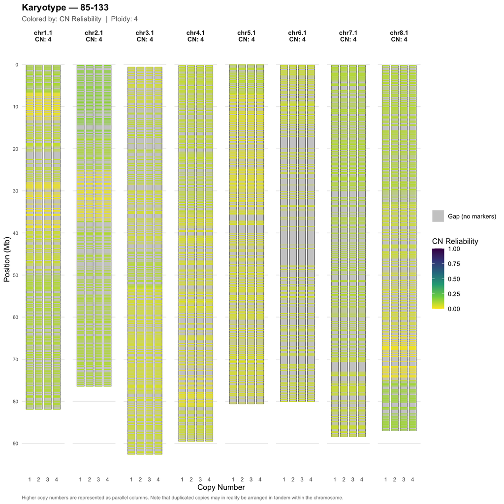

```r
plot_karyotype(multi_esti,
               sample_name = types_df$by_cn$`4x`$euploid[14], color_by = "CN_reliability")
```

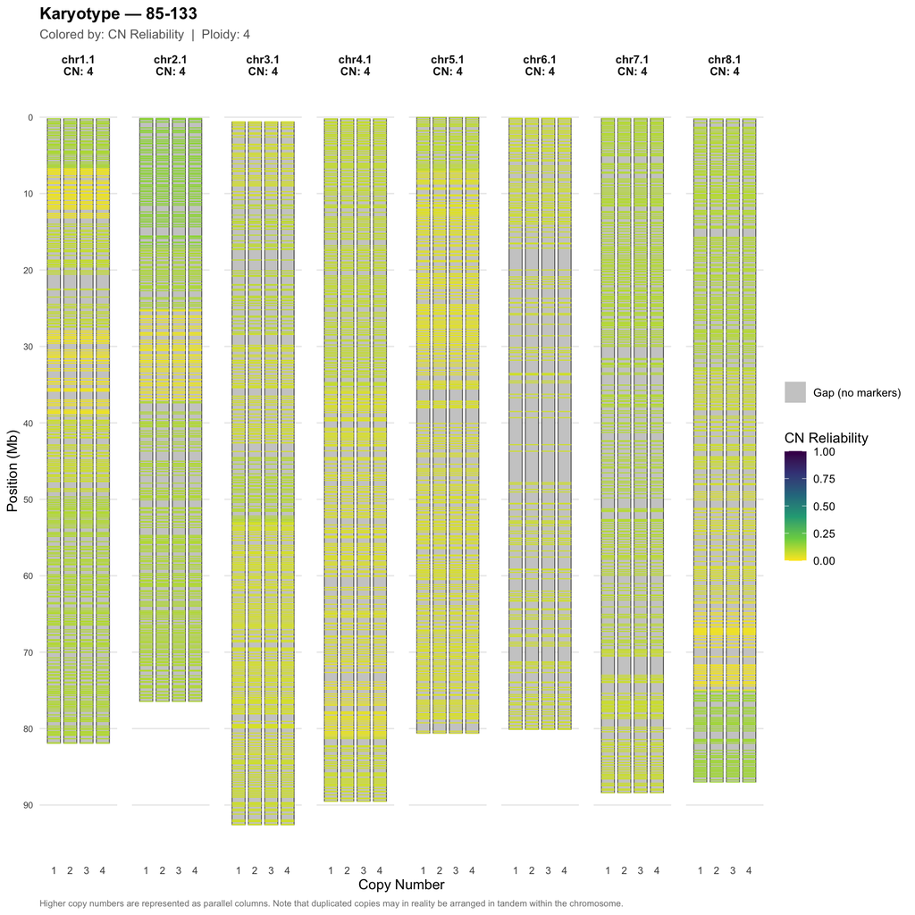

```r
# Option to remove the ghost missing chromosome:
plot_karyotype(multi_esti,
               sample_name = types_df$by_cn$`4x`$euploid[14], color_by = "CN_reliability", add_ghost = FALSE)
```

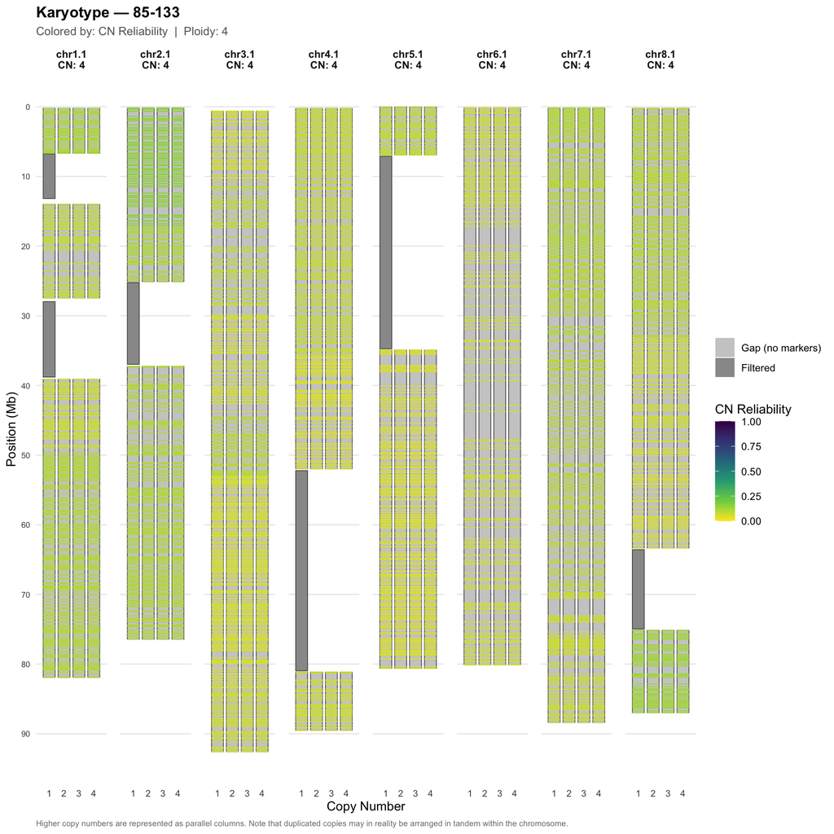

```r
plot_karyotype(multi_esti_filtered,
               sample_name = types_df$by_cn$`4x`$euploid[14], color_by = "CN_reliability")
```

`compare_cn_track_summary()` produces a karyotype-style matrix with samples in rows and chromosomes in columns. Samples are ordered by ascending sample-level CN and, within each CN block, by ploidy category (euploid → aneuploid → segmental). Chromosomes with mixed CN within their windows are shown in purple (segmental aneuploidy); others follow the same blue/gray/red palette as `compare_cn_track()`. Strong horizontal lines separate CN blocks; dashed lines separate the ploidy-category sub-blocks; group labels appear to the right:

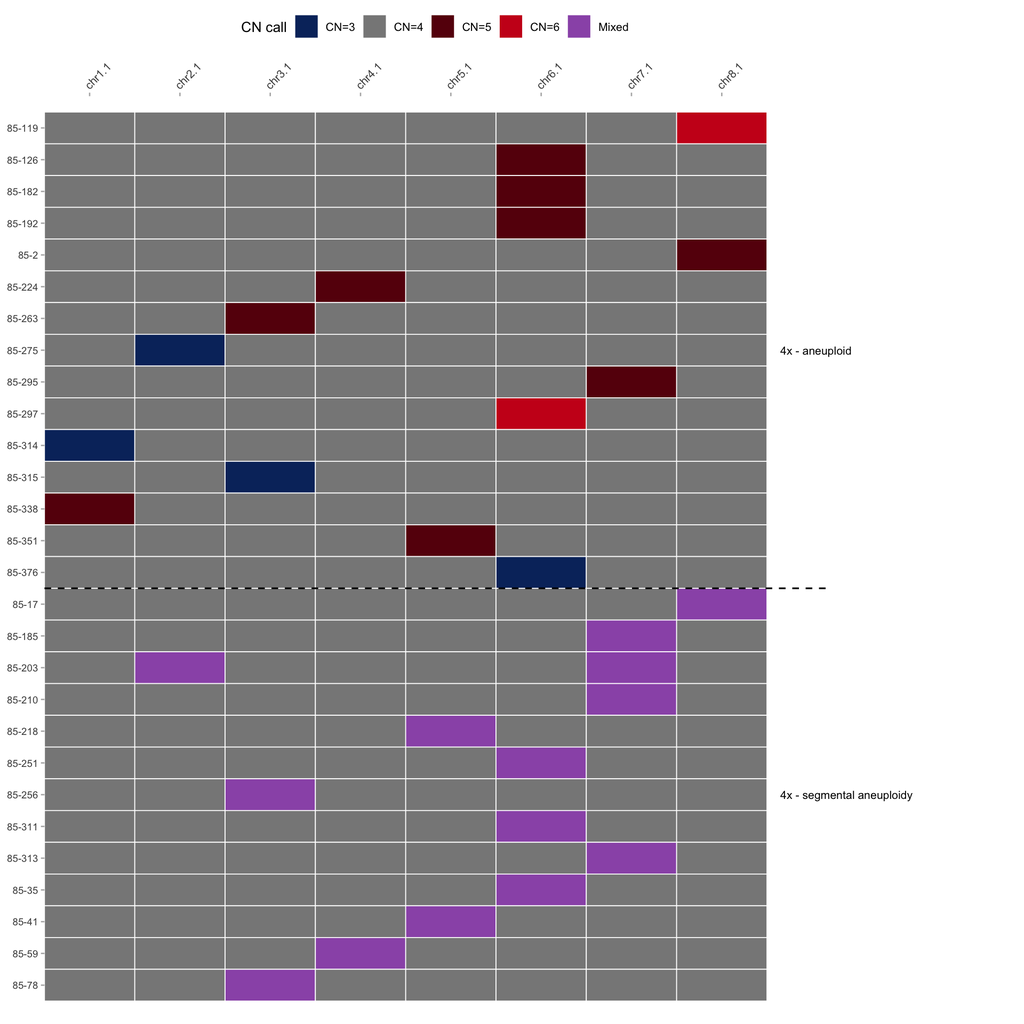

```r
p_summ <- compare_cn_track_summary(multi_esti,
                                   samples_to_plot = c(types_df$aneuploid,types_df$segmental))
p_summ
```

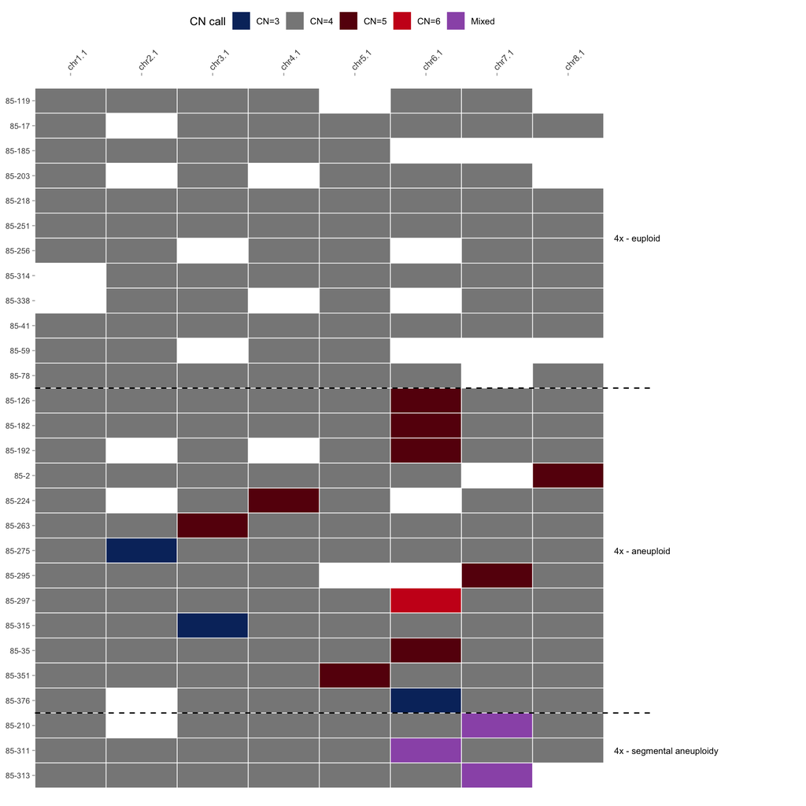

```r
p_summ <- compare_cn_track_summary(multi_esti_filtered,
                                   samples_to_plot = c(types_df$aneuploid,types_df$segmental))
p_summ
```

You can plot specific samples of interest by providing a vector of sample IDs to the `samples_to_plot` argument.

# 13 Re-standardization (Optional)

If you want to improve BAF resolution (e.g., after identifying a subset of samples with known ploidy via HMM), re-standardize:

```r
re_qploidy_standardization <- re_standardize(
  data = data,
  geno.pos = geno.pos,
  hmm_CN_multi  = multi_esti_filtered,
  use_estimated_dosages = TRUE,
  ploidy.standardization = 4,
  threshold.n.clusters = 4,
  threshold.missing.geno = 0.9,
  min.depth = 30,
  max.depth = 600,
  n.cores = 2,
  out_filename = "re_standardization.tsv.gz",
  verbose = TRUE
)

re_qploidy_standardization
```

```
## This is an object of class 'qploidy_standardization'
## --------------------------------------------------------------------
## Parameters
##
## 1 Standardization type:                             intensities
## 2 Ploidy:                                           4
## 3 Min # of heterozygous classes (clusters) present: 4
## 4 Max proportion of missing genotype by marker:     0.9
## 5 Max proportion of missing genotype by sample:     1
## 6 Min genotype probability:                         0.5
## 7 Min read depth (min.depth):                       30
## 8 Max read depth (max.depth):                       600
## --------------------------------------------------------------------
## Filters
##
## 1  # markers at raw data:                             2766  (100%)
## 2  # individuals in standardized data:                185   -
## 3  % datapoints filtered by low probability:          -     (0.03 %)
## 4  # datapoints filtered by depth (min/max):          84309 -
## 5  # samples filtered by missing data:                0     -
## 6  # markers filtered by missing data:                1883  (68.08 %)
## 7  # markers filtered by min number of clusters:      36    (1.3 %)
## 8  # markers filtered by lack of genomic information: 0     (0 %)
## 9  # markers remaining with estimated BAF:            745   (26.93 %)
## 10 # markers remaining with estimated z-score:        2664  (96.31 %)
```

If argument `use_estimated_dosages` is set to TRUE, Qploidy2 estimates the dosage based on its own algorithm. If FALSE, it uses the dosages contained in the initial genos object.

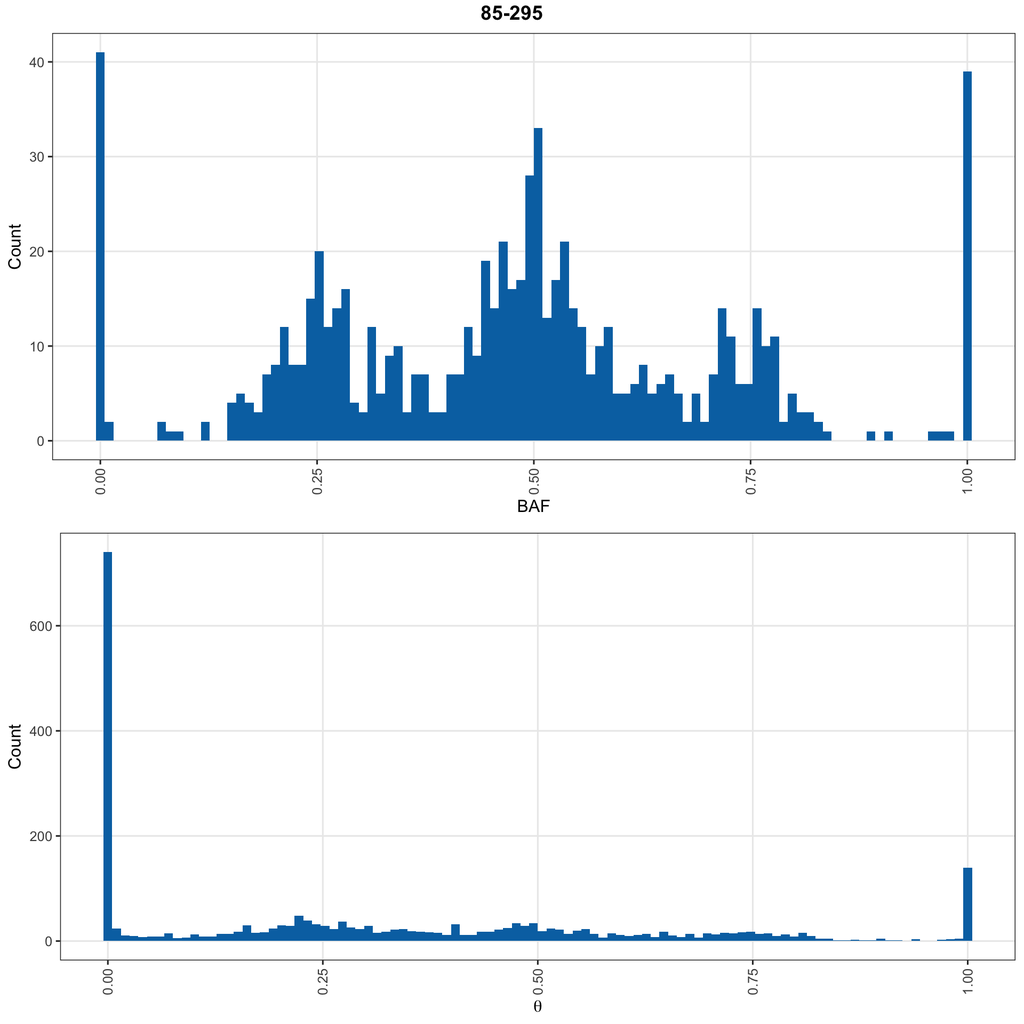

```r
# Compare before and after
plot_qploidy_standardization(x = qploidy_standardization,
                             sample = "85-295",
                             type = c("Ratio_hist_overall", "BAF_hist_overall"))
```

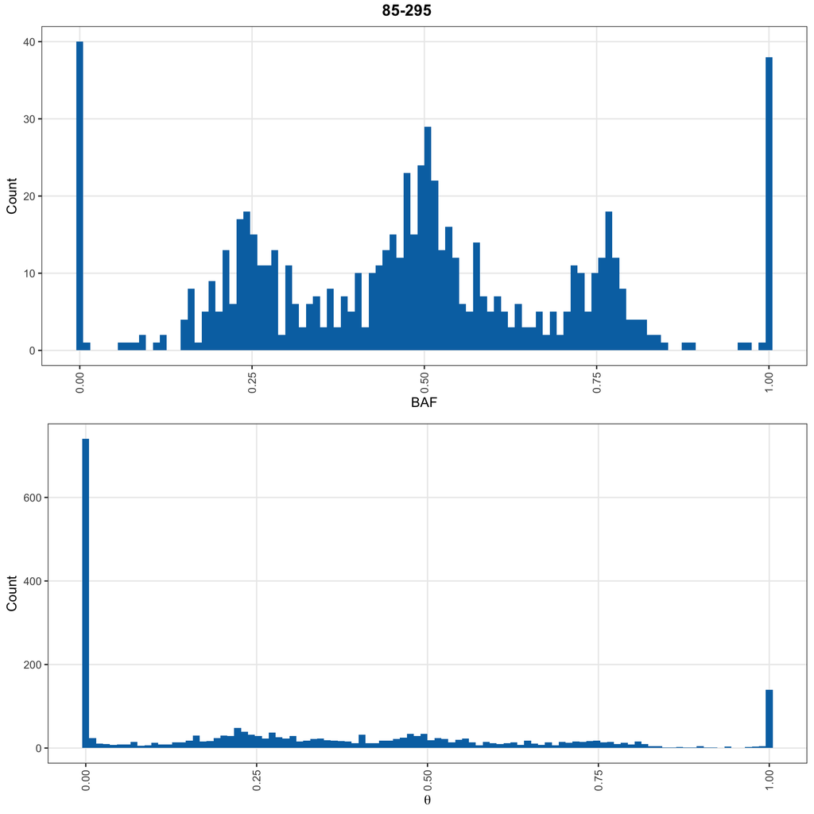

```r
plot_qploidy_standardization(x = re_qploidy_standardization,
                             sample = "85-295",
                             type = c("Ratio_hist_overall", "BAF_hist_overall"))
```